# Temperature data option calculation

- Show All Code
- Hide All Code
- View Source

Author

Affiliation

Pietro Rota

[Università cattolica del sacro cuore](https://www.unicatt.it/)

# 1 Weather Derivatives Temperature Options

**Last updated:** 2025-09-24

**Full dependencies list, click to expand list**

```
[1] "R version 4.4.3 (2025-02-28 ucrt)"
```

```
[1] "x86_64-w64-mingw32/x64"
```

Functions loaded from main

| Functions.1 | Functions.2 | Functions.3 |
| --- | --- | --- |
| bprint | check_acc | compare_cdf |
| desc_df | extract_r_code | find_outliers |
| quickbarplot | quickplot | remove_outliers |
| RSS | show_df | smart_round |

Packages required to run this file

| Required.Packages.1 | Required.Packages.2 | Required.Packages.3 |
| --- | --- | --- |
| caret | colorspace | dplyr |
| DT | e1071 | fBasics |
| forecast | gganimate | ggplot2 |
| gt | gtExtras | knitr |
| leaflet | lubridate | magrittr |
| MASS | mgcv | nlme |
| nlstools | PerformanceAnalytics | plotly |
| purrr | quantmod | reshape2 |
| rugarch | splines | stats4 |
| tibble | tidyr | timeDate |
| timeSeries | TTR | xts |
| zoo |  |  |

Functions defined in this document

| Required.Functions.1 | Required.Functions.2 | Required.Functions.3 |
| --- | --- | --- |
| apply_convolution | sin_component | create_poly_plot |
| fourier_series | create_fourier_plot | create_spline_plot |
| kernel_smooth | create_kernel_plot | create_loess_plot |
| create_gam_plot | T_model | dT_model |
| euler_step | monte_carlo_temp | temperature_option |
| model_formula |  |  |

[output not shown]

```
time of creation
```

```
[1] "2025-09-12 09:36:59 GMT"
```

```
LAST MODIFICATION
```

```
[1] "2025-09-24 12:14:48 GMT"
```

```
Last Access
```

```
[1] "2025-09-24 12:14:48 GMT"
```

```
Last Render
```

```
[1] "2025-09-24 12:15:02 GMT"
```

**References**:

1. Weather Futures and Options (CME Group Inc, 2021) [[LINK](https://www.cmegroup.com/trading/weather/files/weather-fact-card.pdf)]
2. Managing Climate Risk with CME Group Weather Futures and Options (Dominic Sutton-Vermeule, 20-Jan 2021) [[LINK](https://www.cmegroup.com/education/articles-and-reports/managing-climate-risk-with-cme-group-weather-futures-and-options.html)]
3. MANAGING CLIMATE RISK IN THE U.S. FINANCIAL SYSTEM, ISBN: 978-0-578-74841-2 (2020) [LINK]

# 2 Climate data download

Much of the weather market is dominated by temperature derivatives, aimed to protect the holder from unexpected temperature prints. The underlying used to trade these contracts is either Heating Degree Days (HDD) or Cooling Degree Days (CDD). For a specific day n, these can be defined as:

The most popular temperature instruments traded are options, whose payoff function depends on a cumulative sum over a longer period, usually an entire season:

$HDDn = \max(T_{ref} - T_n, 0)$

$CDDn = \max(T_n - T_{ref}, 0)$

Calls protect you from extreme circumstances, meanwhile puts protect you from mild climates

| Option Type | Protection Against | Exercise When | Payout | Example |
| --- | --- | --- | --- | --- |
| HDD call | Overly cold winters | HDD > K | $\alpha \cdot$ (HDD - K) | Farmers |
| HDD **put** | Overly warm winters | HDD < K | $\alpha \cdot$ (K - HDD) | Ski resorts |
| CDD call | Overly hot summers | CDD > K | $\alpha \cdot$ (CDD - K) | Utilities |
| CDD **put** | Overly cold summers | CDD < K | $\alpha \cdot$ (K - CDD) | Beaches |

NASA Prediction Of Worldwide Energy Resources (POWER) | Data Access Viewer (DAV) [[LINK](https://power.larc.nasa.gov/data-access-viewer/)]

This dataset is from the Agroclimatology community, which is crucial for ensuring reproducibility in climate research.

This study utilizes temperature data obtained from the MERRA-2 (Modern-Era Retrospective analysis for Research and Applications, Version 2) dataset, which provides detailed meteorological measurements at a spatial resolution of 0.5 x 0.625 degrees latitude/longitude.

The specific region analyzed, with an average elevation of 288.19 meters, is located at a latitude of 51.5221, and longitude of -0.0903.

```r
library(leaflet, quietly = TRUE, warn.conflicts = FALSE)
map_data <- data.frame(
  name = "Location",
  lat = 51.5221,
  lon = -0.0903
)
# Create a leaflet map
if (knitr::is_html_output()) {
  leaflet(map_data) %>%
    addTiles() %>% # Add default OpenStreetMap tiles
    addCircleMarkers(~lon, ~lat, radius = 5, color = "red", fillOpacity = 0.5) %>%
    setView(lng = map_data$lon, lat = map_data$lat, zoom = 13)
} else {
  print("interactive map of disneyworld in the html version")
}
```

[interactive chart not shown]

Parameter(s):

- T2M_MAX = Temperature at 2 Meters Max for the day (C)
- T2M_MIN = Temperature at 2 Meters Min for the day (C)
- T2M_AVG = $\frac {T_{MIN}+T_{MAX}}2$ Temperature at 2 Meters Average for the day (C)

Temperature at 2 meters refers to the air temperature measured 2 meters (approximately 6.5 feet) above the ground. This is the standard height for temperature measurements used in meteorology because it minimizes the effects of ground heating or cooling, providing a more accurate reflection of the ambient air temperature experienced by humans and relevant to various economic activities.

**Why? Temperature at 2 meters** is commonly used as the basis for weather derivatives. This is because:

- **Standardization**: Temperature at 2 meters is a standardized and widely available data point, making it reliable for use in financial contracts.
- **Relevance**: Many weather-related risks, such as heating degree days (HDD) and cooling degree days (CDD), are calculated based on temperatures at this height. These metrics are commonly used in weather derivatives to hedge against risks related to heating and cooling needs.
- **Accuracy**: Because it represents the temperature most relevant to human activities and energy consumption, it is directly applicable for creating and settling weather derivatives that are based on temperature-related indices.

```r
ORIGINAL_DATASET <- read.csv("London_DATA.csv")

DATASET <- ORIGINAL_DATASET %>%
  mutate(T_MAX=remove_outliers(T2M_MAX, fill = "NA") %>% na.approx) %>%
  mutate(T_MIN=remove_outliers(T2M_MIN, fill = "NA") %>% na.approx) %>%
  mutate(DAY = as.Date(ORIGINAL_DATASET$DOY - 1, origin = paste0(ORIGINAL_DATASET$YEAR, "-01-01"))) %>%
  mutate(Month=month(DAY)) %>%
  dplyr::select(DAY, YEAR, Month, DOY, T_MAX, T_MIN)


DATASET$T_AVG <- apply(DATASET[c("T_MAX", "T_MIN")], 1, mean)
sens_misfunctions <- sum(ifelse(find_outliers(ORIGINAL_DATASET$T2M_MAX)==0,FALSE,TRUE))

if (sens_misfunctions == 0) {
  print("No days where the sensors misfunctioned")
} else{
  ORIGINAL_DATASET[ifelse(find_outliers(ORIGINAL_DATASET$T2M_MAX)==0,FALSE,TRUE),] %>%
  group_by(YEAR) %>%
  summarise("Days" = length(DOY)) %>%
  ggplot( aes(x = YEAR, y = Days))+
    geom_bar(stat = "identity") +
    labs(x= NULL, y =NULL, title = "Days where the sensor malfunctioned",
        subtitle = "Identified by remove outliers")
}
```

```
[1] "No days where the sensors misfunctioned"
```

```r
if (knitr::is_html_output()) {
DATASET %>% select(DAY, T_MAX, T_MIN, T_AVG) %>%
  smart_round(digits = 3) %>%
  datatable() %>%
  formatStyle("T_MAX",
  background = styleColorBar(range(DATASET$T_MAX), "indianred3"),
  backgroundSize = "100% 80%",
  backgroundRepeat = "no-repeat"
  )
  } else {
  print("interactive table of the data in the html version")
}
```

|  | DAY | T_MAX | T_MIN | T_AVG |
| --- | --- | --- | --- | --- |
| 1 | 1982-01-01 | 4.16 | 1.13 | 2.645 |
| 2 | 1982-01-02 | 10.53 | 0.94 | 5.735 |
| 3 | 1982-01-03 | 9.81 | 7.45 | 8.63 |
| 4 | 1982-01-04 | 10.75 | 7.17 | 8.96 |
| 5 | 1982-01-05 | 9.12 | 1.16 | 5.14 |
| 6 | 1982-01-06 | 0.32 | -3.96 | -1.82 |
| 7 | 1982-01-07 | -0.03 | -4.31 | -2.17 |
| 8 | 1982-01-08 | -1.99 | -3.54 | -2.765 |
| 9 | 1982-01-09 | -1.84 | -4.07 | -2.955 |
| 10 | 1982-01-10 | -1.96 | -6.41 | -4.185 |

[output cut: 15948 more lines]

# 3 Initial data visualization

```r
cleandataset <- DATASET %>%
  select(T_MAX, T_MIN, T_AVG) %>%
  xts(order.by = DATASET$DAY)

desc_df(cleandataset)
```

|  | n | mean | sd | median | trimmed | min | max | range | skew | kurtosis | se | %NA | Q.1% | Q.25% | Q.75% | Q.99% |
| --- | --- | --- | --- | --- | --- | --- | --- | --- | --- | --- | --- | --- | --- | --- | --- | --- |
| T_MAX | 15958 | 14.3595 | 6.4903 | 14.290 | 14.3596 | -6.840 | 34.530 | 41.37 | 0.0196 | -0.7345 | 0.0514 | 0 | 1.1300 | 9.36 | 19.5500 | 27.8600 |
| T_MIN | 15958 | 6.2889 | 4.9606 | 6.480 | 6.3782 | -8.990 | 18.900 | 27.89 | -0.1434 | -0.6944 | 0.0393 | 0 | -4.1543 | 2.58 | 10.1600 | 15.9343 |
| T_AVG | 15958 | 10.3242 | 5.5871 | 10.325 | 10.3765 | -7.705 | 26.205 | 33.91 | -0.0570 | -0.7346 | 0.0442 | 0 | -1.3122 | 6.06 | 14.8188 | 21.5622 |

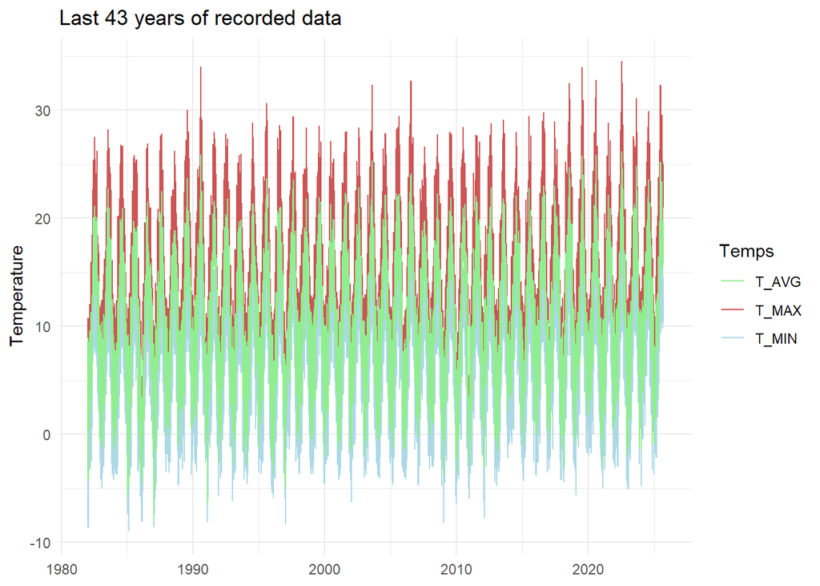

```r
plot1 <- cleandataset %>%
  as.data.frame() %>%
  mutate(year = index(cleandataset)) %>%
  ggplot(aes(x=year))+
  geom_line(aes(y=T_MAX, color = "T_MAX"))+
  geom_line(aes(y=T_MIN, color = "T_MIN"))+
  geom_line(aes(y=T_AVG, color = "T_AVG"))+
  labs(title = "Last 43 years of recorded data", y="Temperature", x=NULL)+
  scale_color_manual(name = "Temps",
                    values = c(T_MAX = "indianred3",T_MIN = "lightblue",T_AVG = "lightgreen"))

plot1
```

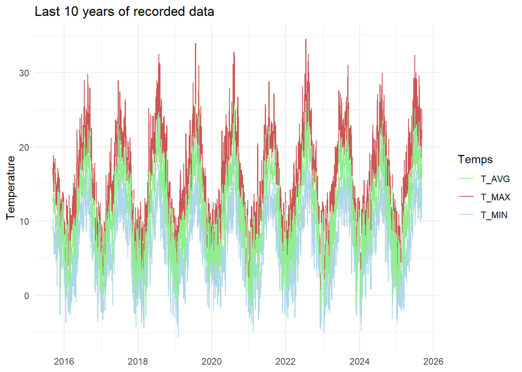

```r
NDAYS <- nrow(cleandataset)
lookback <- 365*10

tail(cleandataset, lookback) %>%
  as.data.frame() %>%
  mutate(year = index(tail(cleandataset, lookback))) %>%
  ggplot(aes(x = year))+
  geom_line(aes(y=T_MAX, color = "T_MAX"))+
  geom_line(aes(y=T_MIN, color = "T_MIN"))+
  geom_line(aes(y=T_AVG, color = "T_AVG"))+
  labs(title = "Last 10 years of recorded data", y="Temperature", x=NULL)+
  scale_color_manual(name = "Temps",
                    values = c(T_MAX = "indianred3",T_MIN = "lightblue",T_AVG = "lightgreen"))
```

```r
library(gganimate)

months365 <- c()  # initialize empty vector

for (i in month.abb) {
  months365 <- c(months365, i, rep(" ", 4))
}
monthplot <- months365[-52][-47][-40][-33][-22][-13][-8]

plot_data <- cleandataset %>%
  as.data.frame() %>%
  mutate(
    date = index(cleandataset),
    year = year(date),
    month = month(date),
    week = week(date)
  ) %>%
  group_by(year, week) %>%
  summarise(T_AVG = mean(T_AVG), .groups = 'drop') %>%
  arrange(year, week)

if (knitr::is_html_output()) {
funny_plot <- ggplot(plot_data, aes(x = factor(week), y = T_AVG, group = year, color = T_AVG)) +
  geom_line(linewidth = 1.2, show.legend = FALSE) +
  coord_polar() +
  scale_x_discrete(breaks = 1:53, labels = monthplot) +
  scale_color_gradient(low = "blue", high = "red") +
  labs(subtitle = "Year: {frame_time}", x = NULL, y = NULL) +
  transition_reveal(year)

animate(funny_plot, fps = 30, duration = 15, end_pause =120)
} else {
print("animated plot in html")
}
```

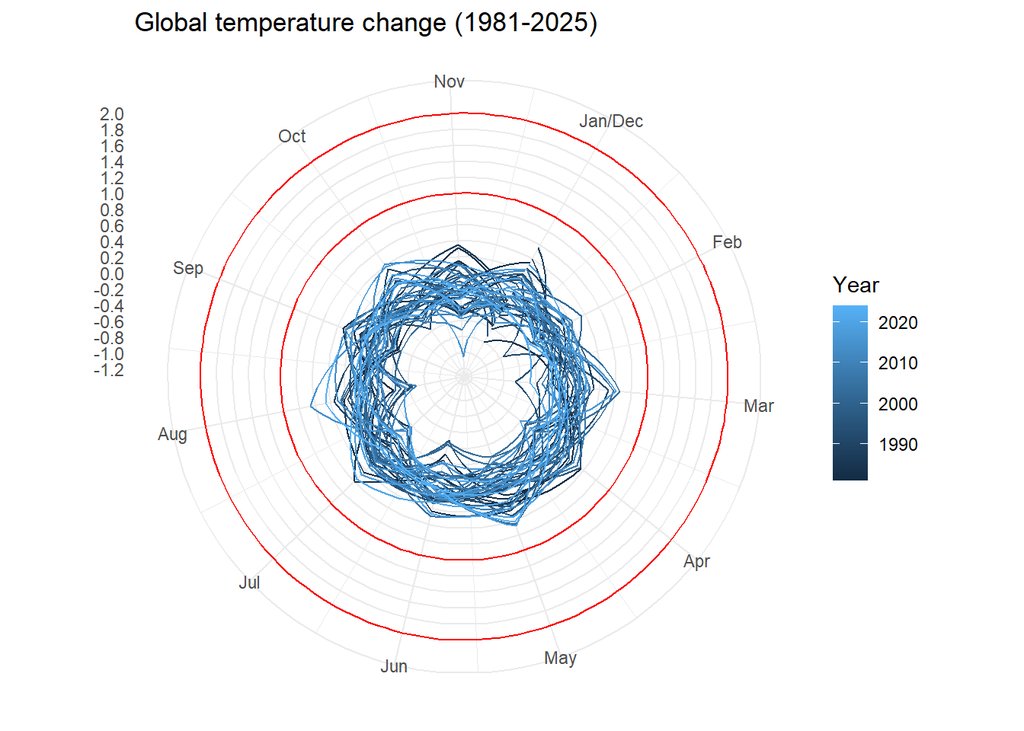

```r
pivot_df <- DATASET %>%
  mutate(t_diff = c(NA, diff(T_AVG))) %>%
  select(Month, YEAR, t_diff) %>%
  pivot_wider(names_from = YEAR, values_from = t_diff, values_fn = median) %>%
  mutate(Month = month.abb) %>%
  melt(id.vars = "Month", variable.name = "Year") %>%
  arrange(Year) %>%
  drop_na() %>%
  mutate(Year = as.integer(Year)+1980)

last_dec <- pivot_df %>%
  filter(Month == "Dec") %>%
  mutate(Year = Year - 1,
  Month = "last_Dec")

next_jan <- pivot_df %>%
  filter(Month == "Jan") %>%
  mutate(Year = Year + 1,
  Month = "Next_jan")

t_data <- bind_rows(pivot_df, next_jan) %>%
  mutate(Month = factor(Month, levels = c(month.abb, "next_Jan")),
         Month_number = as.numeric(Month)) %>% drop_na()

annotation <- t_data %>%
  slice_max(Year-1) %>%
  slice_max(Month_number)

temp_lines <- tibble(
  x = 12,
  y = c(1.5, 2.0),
  labels = c("1.5\u00B0C", "2.0\u00B0C")
)

month_labels <- tibble(
  x = 1:12,
  labels = month.abb,
  y = 2.7
)

t_data %>%
  ggplot(aes(x=Month_number, y=value, group=Year, color=Year)) +
  geom_hline(yintercept = c(1, 2.0), color="red") +
  geom_line() +
  scale_x_continuous(breaks=1:12,
                    labels=month.abb, expand = c(0,0),
                    sec.axis = dup_axis(name = NULL, labels=NULL)) +
  scale_y_continuous(breaks = seq(-2, 2, 0.2),
                    limits = c(-2, 2.7), expand = c(0, -0.7),
                    sec.axis = dup_axis(name = NULL, labels=NULL)) +
  coord_polar(start = 2*pi/12) +
  labs(x = NULL,
      y = NULL,
      title = "Global temperature change (1981-2025)")
```

## 3.1 Overlap of the dataset

One of the points that i would need for later is the standard deviation across the days of year, a pivot table is used for this step as with this I’m able to line up all the dataset month to month, by doing this im also able to analize seasonal patterns and look at the seasonality at a glance

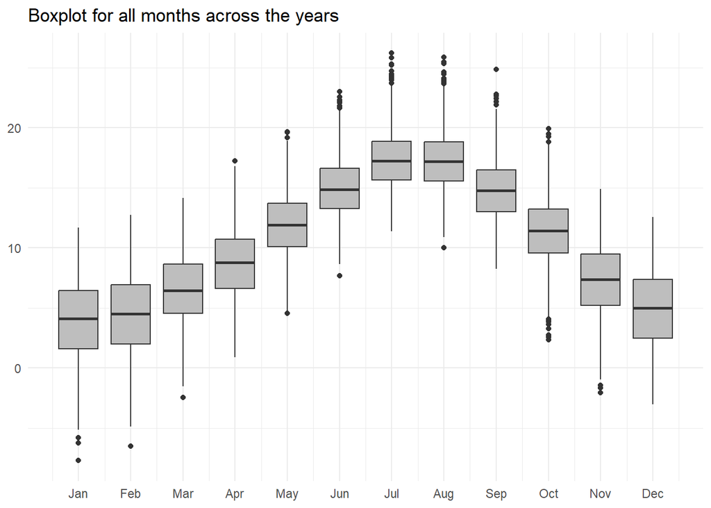

```r
pivot_df <- DATASET %>%
  select(DOY, YEAR, T_AVG) %>%
  pivot_wider(names_from = YEAR, values_from = T_AVG)


MAX_pivot_df <- DATASET %>%
  select(DOY, YEAR, T_MAX) %>%
  pivot_wider(names_from = YEAR, values_from = T_MAX)

MIN_pivot_df <- DATASET %>%
  select(DOY, YEAR, T_MIN) %>%
  pivot_wider(names_from = YEAR, values_from = T_MIN)

DATASET %>%
  select(Month, T_AVG) %>%
  group_by(Month) %>%
  ggplot(aes(x = Month, y = T_AVG, group = Month)) +
    geom_boxplot(fill = "gray") +
    scale_x_continuous(breaks = seq(1, 12, by = 1), labels = month.abb) +
    labs(title = "Boxplot for all months across the years", x = NULL, y = NULL)
```

### 3.1.1 How is this year compared to the rest

This dataset is 43 years long and there have been some really hot points and some really cold points over the years, so i wanted to look at my dataset and create a ribbon of all the max and mins, to see if this year has been so hot when looking at the averages, while this is in no way conclusive evidence it at least gives you a glimpse at how the climate is changing especially when looking at the middle of the year.

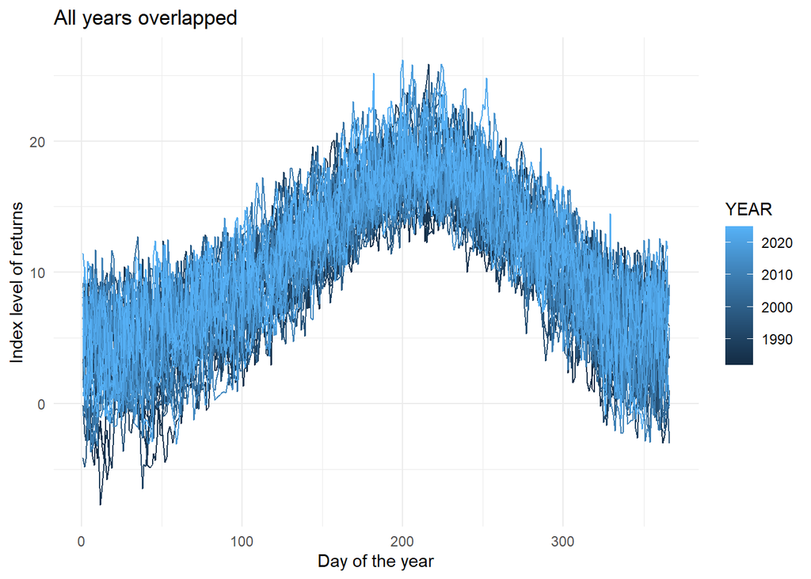

```r
ggplot(DATASET, aes(x = DOY, y = T_AVG, group = YEAR, color = YEAR)) +
  geom_line() +
  labs(title = "All years overlapped", x = "Day of the year", y = "Index level of returns")
```

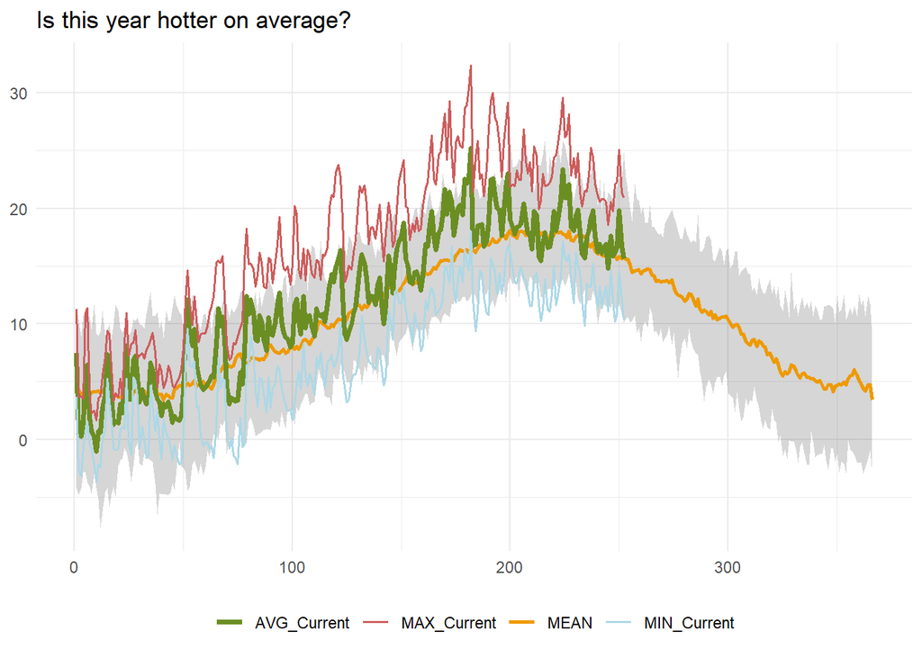

```r
THISYEAR <- data.frame(
  c(DATASET[DATASET$YEAR == 2025, ]["T_MAX"]),
  c(DATASET[DATASET$YEAR == 2025, ]["T_AVG"]),
  c(DATASET[DATASET$YEAR == 2025, ]["T_MIN"])
)

cbind(pivot_df,
      "MIN" = apply(pivot_df[-1], 1, min, na.rm = TRUE),
      "MAX" = apply(pivot_df[-1], 1, max, na.rm = TRUE),
      "MEAN" = apply(pivot_df[-1], 1, mean, na.rm = TRUE)) %>%
  round(2) %>%
  ggplot(aes(x = DOY)) +
    geom_ribbon(aes(ymin = MIN, ymax = MAX), alpha = 0.2) +
    geom_line(aes(y = MEAN, color = "MEAN"), linewidth = 1) +
    geom_line(aes(y = pivot_df$`2025`, color = "AVG_Current"), linewidth = 1.3) +
    geom_line(aes(y = MAX_pivot_df$`2025`, color = "MAX_Current"), linewidth = 0.6, alpha = 1) +
    geom_line(aes(y = MIN_pivot_df$`2025`, color = "MIN_Current"), linewidth = 0.6, alpha = 1) +
  scale_color_manual(name = NULL, values = c(MEAN = "orange2", AVG_Current = "olivedrab",
                                                MIN_Current = "lightblue", MAX_Current = "indianred")) +
  labs(title = "Is this year hotter on average?", y = NULL, x = NULL)+
  theme(legend.position = "bottom")
```

## 3.2 Seasonal analysis

Now i can look at the distribution of my database, first i need to distinguish the data between summer periods and winter periods by taking the day of the year and splitting it so that

Winter ~ October-March

Summer ~ April-September

```r
DATASET_seas <- DATASET %>%
  group_by(Month < 4|Month>9) %>%
  rename("Season"="Month < 4 | Month > 9") %>%
  mutate(Season = ifelse(Season, "Winter", "Summer"))

DATASET_seas[-1] %>%
  xts(order.by = DATASET$DAY)%>%
  show_df() %>%
  gt() %>%
  tab_header(title = "Temperature Overview") %>%
  opt_stylize(style = 5, add_row_striping = TRUE) %>%
  cols_align(align = "center") %>%
  sub_missing(columns = everything(), missing_text = "⋮")
```

Temperature Overview

| DATE | YEAR | Month | DOY | T_MAX | T_MIN | T_AVG | Season |
| --- | --- | --- | --- | --- | --- | --- | --- |
| 1982-01-01 | 1982 | 1 | 1 | 4.16 | 1.13 | 2.645 | Winter |
| 1982-01-02 | 1982 | 1 | 2 | 10.53 | 0.94 | 5.735 | Winter |
| 1982-01-03 | 1982 | 1 | 3 | 9.81 | 7.45 | 8.630 | Winter |
| 1982-01-04 | 1982 | 1 | 4 | 10.75 | 7.17 | 8.960 | Winter |
| 1982-01-05 | 1982 | 1 | 5 | 9.12 | 1.16 | 5.140 | Winter |
| ⋮ | ⋮ | ⋮ | ⋮ | ⋮ | ⋮ | ⋮ | ⋮ |
| 2025-09-05 | 2025 | 9 | 248 | 22.08 | 10.17 | 16.125 | Summer |
| 2025-09-06 | 2025 | 9 | 249 | 22.29 | 10.93 | 16.610 | Summer |
| 2025-09-07 | 2025 | 9 | 250 | 25.06 | 14.59 | 19.825 | Summer |
| 2025-09-08 | 2025 | 9 | 251 | 21.37 | 12.09 | 16.730 | Summer |
| 2025-09-09 | 2025 | 9 | 252 | 20.95 | 10.37 | 15.660 | Summer |

```r
winter_dataset <- DATASET_seas[DATASET_seas$Season=="Winter",]
summer_dataset <- DATASET_seas[DATASET_seas$Season=="Summer",]

cat(paste0("The difference in number of rows is approximately: ", round(nrow(summer_dataset) / nrow(winter_dataset) - 1, 4)*100,"%", ", or ", round((nrow(summer_dataset) / nrow(winter_dataset) - 1)*NDAYS, 1), " days"))
```

```
The difference in number of rows is approximately: 1.31%, or 209.4 days
```

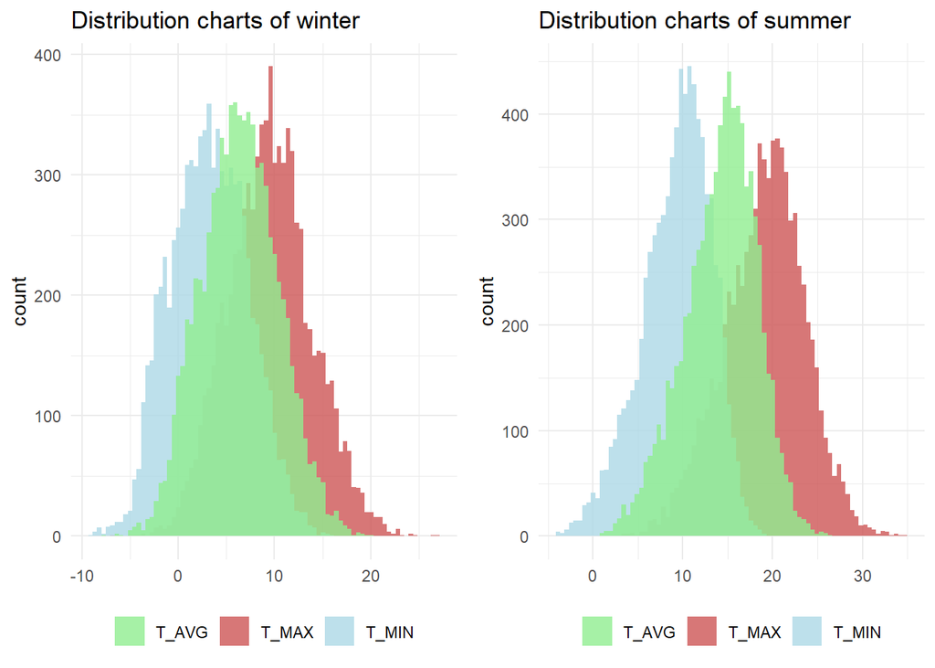

```r
grid.arrange(ncol=2,
ggplot(winter_dataset)+
  geom_histogram(aes(x = T_MAX, fill = "T_MAX"), alpha=0.8, bins = 80)+
  geom_histogram(aes(x = T_MIN, fill = "T_MIN"), alpha=0.8, bins = 80)+
  geom_histogram(aes(x = T_AVG, fill = "T_AVG"), alpha=0.8, bins = 80)+
  labs(title = "Distribution charts of winter",x=NULL)+
  scale_fill_manual(name = NULL,
                    values = c(T_MAX = "indianred3",T_MIN = "lightblue",T_AVG = "lightgreen"))+
  theme(legend.position = "bottom")

,

ggplot(summer_dataset)+
  geom_histogram(aes(x = T_MAX, fill = "T_MAX"), alpha=0.8, bins = 80)+
  geom_histogram(aes(x = T_MIN, fill = "T_MIN"), alpha=0.8, bins = 80)+
  geom_histogram(aes(x = T_AVG, fill = "T_AVG"), alpha=0.8, bins = 80)+
  labs(title = "Distribution charts of summer",x=NULL)+
  scale_fill_manual(name = NULL,
                    values = c(T_MAX = "indianred3",T_MIN = "lightblue",T_AVG = "lightgreen"))+
  theme(legend.position = "bottom")

)
```

Lastly I’m able to plot just the two average temperatures of winter and of summer for the average temperatures

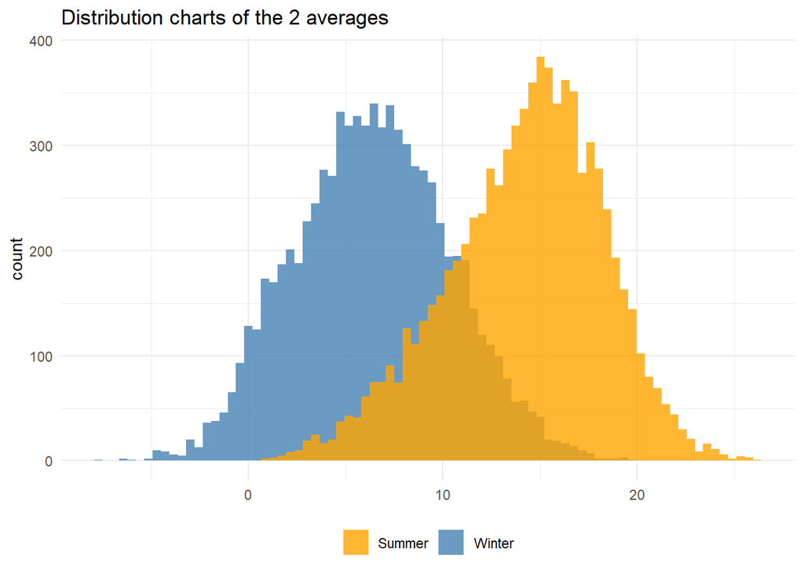

```r
ggplot()+
  geom_histogram(data = winter_dataset, aes(x = T_AVG, fill = "Winter"), alpha=0.8, bins = 80)+
  geom_histogram(data = summer_dataset, aes(x = T_AVG, fill = "Summer"), alpha=0.8, bins = 80)+
  labs(title = "Distribution charts of the 2 averages",x=NULL)+
    scale_fill_manual(name = NULL,
                    values = c(Winter="steelblue", Summer="orange"))+
  theme(legend.position = "bottom")
```

Just to understand the records of my dataset i wanted to see what months on record had the hottest and coldest days across all dataset

```r
DATASET_seas %>%
  group_by(Month) %>%
  summarise(T_min_min = min(T_MIN),
            T_min_max = max(T_MIN),
            T_max_min = min(T_MAX),
            T_max_max = max(T_MAX)) %>%
  round(3) %>%
  mutate(Month = month.abb) %>%
  gt() %>%
  opt_stylize(5) %>%
  tab_header("Data exploration", "what is the highest and lowest in my database") %>%
  cols_label(T_min_min = "Min",
              T_min_max = "Max",
              T_max_min = "Min",
              T_max_max = "Max") %>%
  tab_spanner(label = "T_MIN", columns = 2:3) %>%
  tab_spanner(label = "T_MAX", columns = 4:5)
```

Data exploration

what is the highest and lowest in my database

| Month | T_MIN Min | T_MIN Max | T_MAX Min | T_MAX Max |
| --- | --- | --- | --- | --- |
| Jan | -8.64 | 10.73 | -6.84 | 13.14 |
| Feb | -8.99 | 10.72 | -4.85 | 16.88 |
| Mar | -5.24 | 9.97 | -0.43 | 20.44 |
| Apr | -4.11 | 11.65 | 3.54 | 25.19 |
| May | -0.66 | 14.17 | 7.49 | 26.47 |
| Jun | 1.68 | 17.27 | 11.79 | 30.42 |
| Jul | 5.60 | 18.86 | 15.10 | 34.53 |
| Aug | 5.48 | 18.90 | 13.15 | 34.01 |
| Sep | 2.52 | 18.59 | 10.67 | 31.07 |
| Oct | -2.69 | 16.00 | 6.62 | 27.07 |
| Nov | -4.77 | 12.66 | -0.04 | 17.67 |
| Dec | -5.91 | 11.45 | -1.55 | 13.94 |

## 3.3 Long term trends

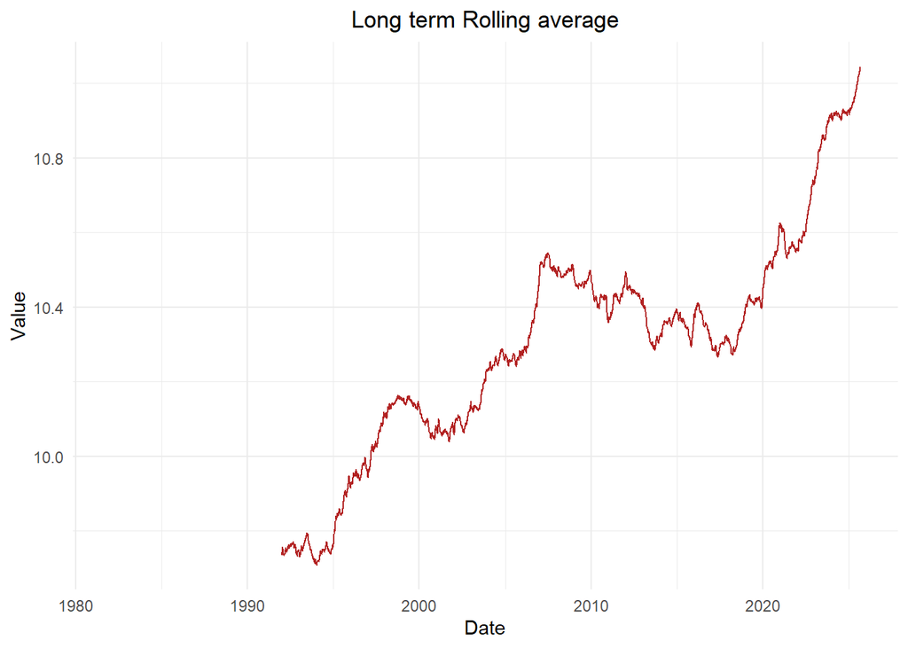

```r
quickplot(SMA(DATASET$T_AVG, lookback), show_legend = F, title = "Long term Rolling average",
  x_start = min(DATASET$YEAR),x_step = 1 / 365.25)
```

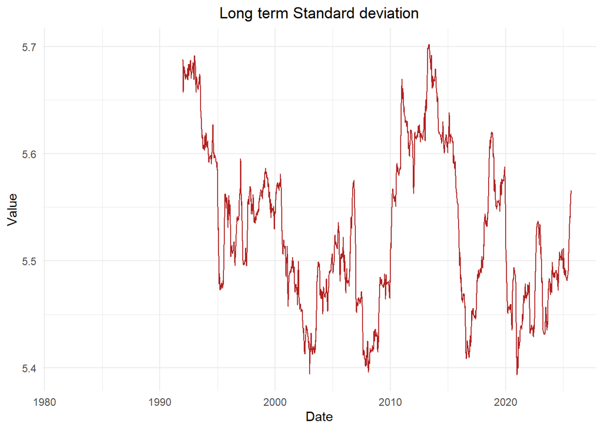

```r
quickplot(
  runSD(DATASET$T_AVG, lookback), show_legend = F, title = "Long term Standard deviation",
  x_start = min(DATASET$YEAR), x_step = 1 / 365.25)
```

# 4 Seasonal decomposition

The first step in pricing temperature options is to decompose the time series into distinct components that each represent different underlying patterns. This process is essential for understanding the structure of the data and for developing predictive models. In basic terms it can be expressed as the sum of three main components:$y_t=T_t+S_t+e_t$, Here, $T_t$ is the trend component that captures the long-term movement, $S_t$ represents the seasonal variations (periodic patterns), and $e_t$ refers to the residuals or noise in the data.

which in our case becomes
$$\overline{T_t} = T_{trend} + T_{seasonal}+ Residuals$$

The approach was to develop each component independently

$$T_{trend} = a + b\cdot t$$

The trend component could be as simple as a straight line or a moving average

This form captures the cyclical nature of temperature changes throughout the year, like daily or annual temperature fluctuations.

$$T_{seasonal} = \alpha \cdot \sin(\omega \cdot t + \theta)$$

- $\alpha$ represents the amplitude
- $\omega$ is the angular frequency (related to the period of the cycle)
- $\theta$ is the phase shift

Recent research has suggested that partial Fourier decomposition can be effective in modeling temperature data, particularly by omitting the cosine component. This approach simplifies the seasonal model while still accurately representing the cyclical nature of temperature changes. The sinusoidal term is often sufficient to describe seasonal temperature variations, making the model both interpretable and computationally efficient.

Before this I used a de-noising procedure using Gaussian Convolution Filter as it also enhances the effectiveness of the Fourier transformation by reducing noise, allowing you to identify the dominant frequencies or cycles in your temperature data more accurately.

- **Gaussian Convolution Filter**:
  - A **convolution** is a mathematical operation used to blend or smooth data. It involves applying a kernel (a small array of weights) across the data to compute a weighted average. The Gaussian kernel is a specific type of convolution filter that assigns weights based on the Gaussian (normal) distribution, which is a bell-shaped curve.
  - The **Gaussian kernel** is widely used for smoothing because it gives more weight to the central points (closer to the middle) while gradually reducing the weights for points further away. This is mathematically expressed as:

$$G(x)=\frac{1}{\sqrt{2π\sigma^2}}\cdot e^{-\frac{x^2}{2\sigma^2}}$$

- **Moving Window**: The Gaussian kernel slides across each point in the time series. For each position, it computes a weighted sum where the weights are defined by the Gaussian kernel.
- **Local Averaging**: The computed value represents a smoothed average of the points within the window’s range. Points closer to the center of the window contribute more heavily to the average than those farther away, as per the Gaussian weights.
- **Symmetric Filtering**: using 2 sides makes this operation symmetric, applying the kernel both forward and backward across the data, ensuring the filtering effect is centered.
- **Conclusion and data inspection**: in visual terms the de-noised data should look smoother with slightly lower peaks

```r
temps <- DATASET
apply_convolution <- function(x, kernel) {
  # Use filter() from stats package to apply convolution
  filtered <- stats::filter(x, kernel, sides = 2)  # Use sides = 2 for symmetric filter
  return(filtered)
}

kernel <- dnorm(-3:3)
data.frame("Gaussian_Kernel" = round(kernel, 10))
```

| Gaussian_Kernel |
| --- |
| 0.0044318 |
| 0.0539910 |
| 0.2419707 |
| 0.3989423 |
| 0.2419707 |
| 0.0539910 |
| 0.0044318 |

```r
temps$Denoised <- apply_convolution(temps$T_AVG, kernel)
temps$Denoised <- na.fill(temps$Denoised, mean(temps$Denoised, na.rm = TRUE))

temps$Trend <- SMA(temps$Denoised, n = lookback)

library(nlme, quietly = T, warn.conflicts = F)

# Define the model
sin_component <- function(t, a, b, alpha, theta) {
  omega <- 2 * pi / 365.25
  a + b * t + alpha * sin(omega * t + theta)
}
omega <- 2 * pi / 365.25

# Fit model using non linear squares
temps$NUM_DAY <- 1:nrow(temps)

fit <- nls(Denoised ~ sin_component(NUM_DAY, a, b, alpha, theta),
          data = temps,
          start = list(a = 1, b = 0, alpha = 1, theta = 0))


# Get coefficients and confidence intervals for the model
MOD_params <- coef(fit)
confint_fit <- suppressMessages(confint(fit))

temps$SEAS <- MOD_params["alpha"] * sin(omega * temps$NUM_DAY + MOD_params["theta"])
temps$TREND <- MOD_params["a"] + MOD_params["b"] * temps$NUM_DAY
temps$BAR <- temps$TREND + temps$SEAS
temps$RESID <-  temps$T_AVG - temps$TREND - temps$SEAS
```

just to be certain i looked at if the residuals and the fitted values matched the $\overline T$ and $Residuals$ by checking percentage of same values as the rounding decimals increase The logic is that if the data sets are anything alike (like 2 different models results for the same dataset) you should see how far in the rounding are the data sets similar

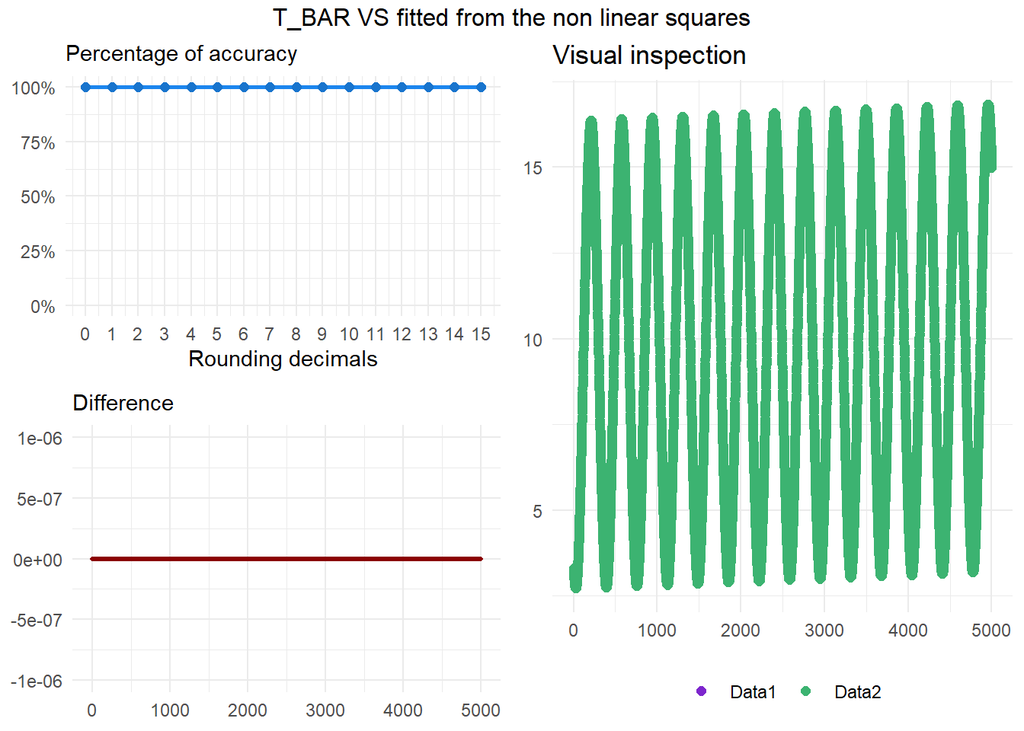

```r
check_acc(temps$BAR, fitted(fit),15, title = "T_BAR VS fitted from the non linear squares")
```

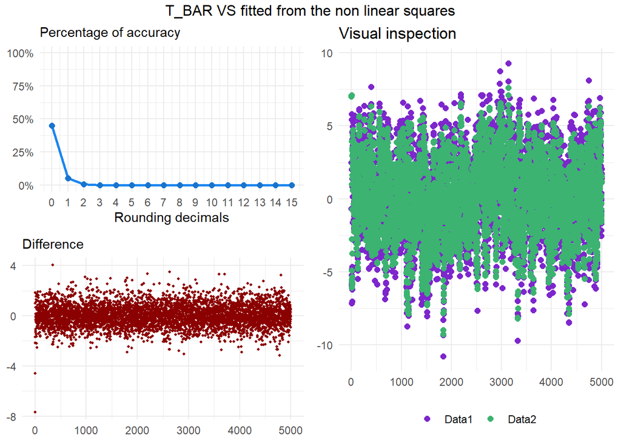

```r
check_acc(temps$RESID, residuals(fit),15, title = "T_BAR VS fitted from the non linear squares")
```

## 4.1 Model performance

for assessing my model performance I’m looking at the values and confidence intervals and looking at the Residual sum of squares and the mean absolute error

- The **RSS function** calculates the Residual Sum of Squares, which is a measure of the discrepancy between the observed data and the model’s predictions. A lower RSS indicates a better fit of the model to the data, meaning that the model’s predictions are closer to the actual observed values.
- The **MAE function** is the average of the absolute differences between the observed and predicted values. It gives an idea of how far, on average, the predictions are from the actual values, without considering the direction of the error. A lower MAE indicates that the model’s predictions are generally close to the observed data.

```
a :  9.533  CI ~normally [ 9.458 , 9.608 ]
b :  0  CI ~normally [ 0 , 0 ]
alpha :  -6.814  CI ~normally [ -6.867 , -6.761 ]
theta :  -5.147  CI ~normally [ -5.155 , -5.14 ]
```

```
  RSS model sine curve: 121777.4
```

```
  MAE model fit: 2.23
```

## 4.2 Visualization of results

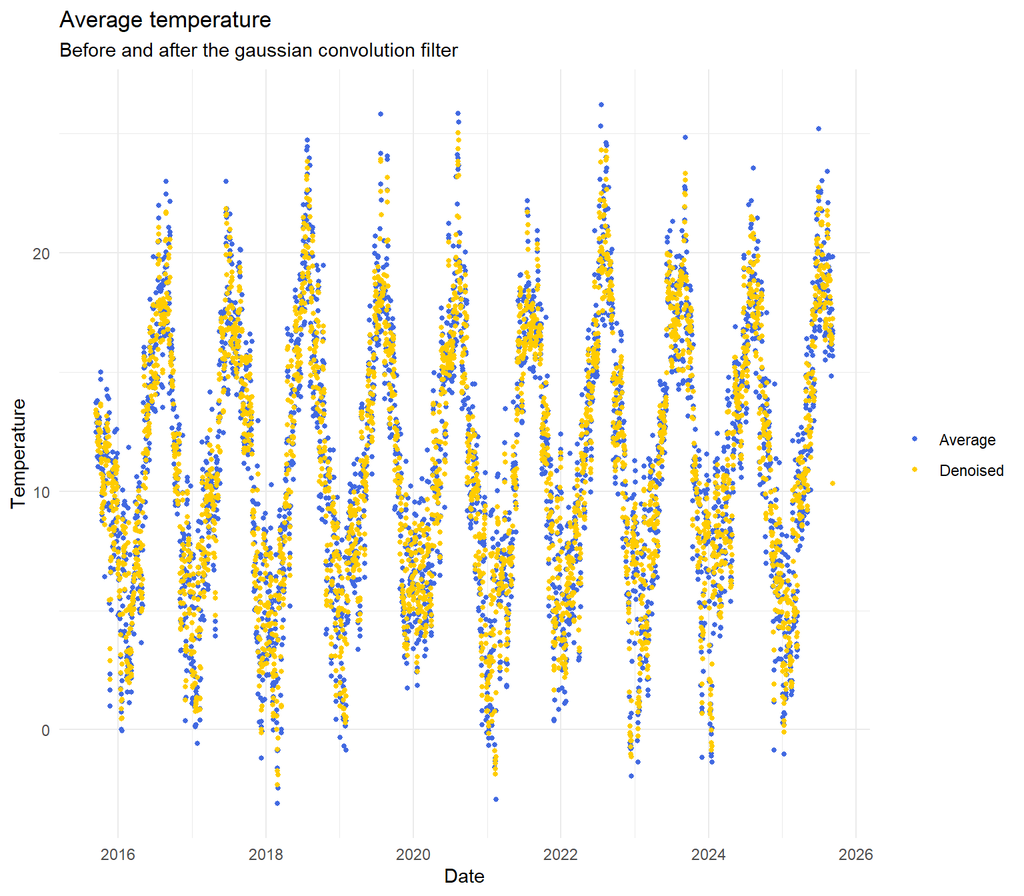

```r
# plot denoised
ggplot(tail(temps, lookback), aes(x=DAY))+
  geom_point(aes(y = T_AVG, color = "Average"), size = 1)+
  geom_point(aes(y = Denoised, color = "Denoised"), size = 1)+
  scale_color_manual(name=NULL, values = c(Average = "royalblue", Denoised = "#ffcc00"))+
  labs(title = "Average temperature", x = "Date", y = "Temperature",
      subtitle = "Before and after the gaussian convolution filter")
```

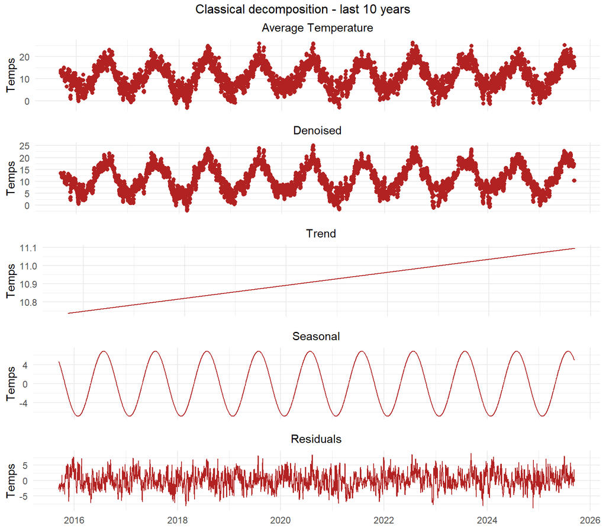

```r
temps_xts <- temps %>%
  select(T_AVG, Denoised, TREND, SEAS, RESID) %>%
  xts(order.by = temps$DAY) %>%
  tail(lookback)

# Plot seasonal decomposition from Avg to residuals
grid.arrange(nrow=5, top = paste0("Classical decomposition - last ",  lookback/365, " years"),

  temps_xts$T_AVG %>%
    quickplot(subtitle = "Average Temperature", show_legend = F, xlab = NULL, ylab = "Temps",
    type = geom_point, show_x = F),

  temps_xts$Denoised %>%
    quickplot(subtitle = "Denoised", show_legend = F, xlab = NULL, ylab = "Temps",
    type = geom_point, show_x = F),

  temps_xts$TREND %>%
    quickplot(subtitle = "Trend", show_legend = F, xlab = NULL, ylab = "Temps" , show_x = F),

  temps_xts$SEAS %>%
    quickplot(subtitle = "Seasonal", show_legend = F, xlab = NULL, ylab = "Temps" , show_x = F),

  temps_xts$RESID %>%
    quickplot(subtitle = "Residuals", show_legend = F, xlab = NULL, ylab = "Temps"))
```

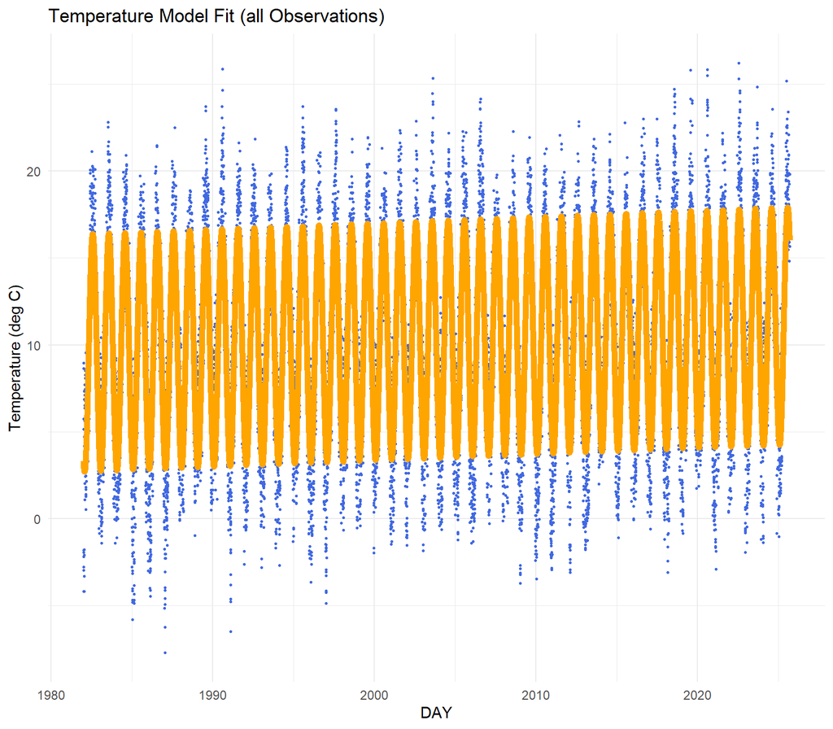

```r
# Plot original vs. fitted data
ggplot(temps, aes(x = DAY)) +
  geom_point(aes(y = T_AVG), color = 'royalblue', size = 0.5) +
  geom_line(aes(y = BAR), color = 'orange', linewidth=2) +
  labs(title = "Temperature Model Fit (all Observations)", y = "Temperature (deg C)")
```

### 4.2.1 Check for possible model degradation

Checking for model degradation across time by looking at the first and last 10 years to see if there is a meaningful shift in where the sine curve and the average temperature

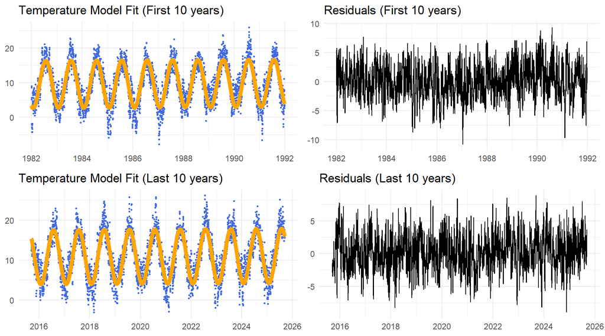

```r
grid.arrange(nrow = 2, ncol = 2,
ggplot(temps %>% head(lookback), aes(x = DAY)) +
  geom_point(aes(y = T_AVG), color = 'royalblue', size = 0.5) +
  geom_line(aes(y = BAR), color = 'orange', linewidth=2) +
  labs(title = paste0("Temperature Model Fit (First ", lookback/365, " years)"),x=NULL, y = NULL),

ggplot(temps %>% head(lookback), aes(x = DAY)) +
  geom_line(aes(y = RESID), color = 'black', linewidth=0.5) +
  labs(title = paste0("Residuals (First ", lookback/365, " years)"),x=NULL, y = NULL),

ggplot(temps %>% tail(lookback), aes(x = DAY)) +
  geom_point(aes(y = T_AVG), color = 'royalblue', size = 0.5) +
  geom_line(aes(y = BAR), color = 'orange', linewidth=2) +
  labs(title = paste0("Temperature Model Fit (Last ", lookback/365, " years)"), x=NULL, y = NULL),

ggplot(temps %>% tail(lookback), aes(x = DAY)) +
  geom_line(aes(y = RESID), color = 'black', linewidth=0.5) +
  labs(title = paste0("Residuals (Last ", lookback/365, " years)"),x=NULL, y = NULL)
)
```

## 4.3 Residuals analysis and diagnostics

1. **Autocorrelation Function (ACF) Plot of Residuals**:

   The ACF plot checks for any correlation between residuals at different lags. If residuals are uncorrelated (i.e., resemble white noise), all values should fall within the confidence bands, indicating no significant autocorrelation.
2. **Partial Autocorrelation Function (PACF) Plot of Residuals**:

   The PACF plot displays the partial correlation of residuals with their own lagged values, considering the effect of any intermediate lags. Like the ACF plot, if the model fits well, the PACF values should also fall within the confidence bands, showing no significant partial autocorrelations.
3. **Normality Check using QQ Plot**:

   The QQ plot assesses whether the residuals are normally distributed. Points should lie along the reference line; significant deviations from this line suggest that the residuals do not follow a normal distribution, which could imply model misspecification or the presence of outliers.
4. **Histogram of Residuals with Normal Curve**:

   The plot checks for patterns in the residuals against fitted values. Ideally, the residuals should be randomly scattered around zero, indicating homoscedasticity (constant variance). Any visible pattern or trend suggests issues like non-linearity, heteroscedasticity, or omitted variables.

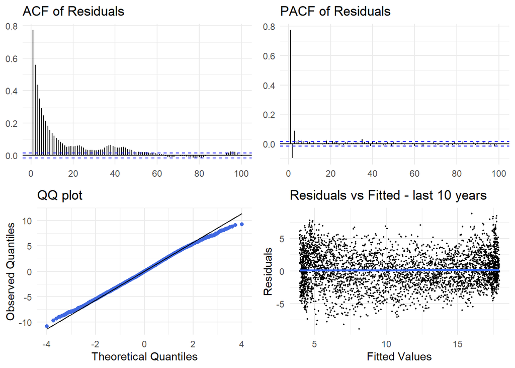

```r
grid.arrange(nrow = 2,
# ACF
ggAcf(temps$RESID, lag.max = 100)+
  labs(title = "ACF of Residuals", x = NULL, y = NULL),

# PACF
ggPacf(temps$RESID, lag.max = 100)+
  labs(title = "PACF of Residuals", x = NULL, y = NULL),

## Check normality of residuals using QQ plot
ggplot(temps, aes(sample = RESID)) +
  stat_qq(color="royalblue")+
  stat_qq_line(color = "black", linewidth = 0.4)+
  labs(title = "QQ plot", x="Theoretical Quantiles", y= "Observed Quantiles"),

## Check for heteroskedasticity or any pattern in residuals
ggplot(temps %>% tail(lookback), aes(x=BAR, y = RESID))+
  geom_point(size = 0.4)+
  geom_smooth(method = "lm")+
  labs(title = paste0("Residuals vs Fitted - last ",  lookback/365, " years"), x= "Fitted Values", y = "Residuals"))
```

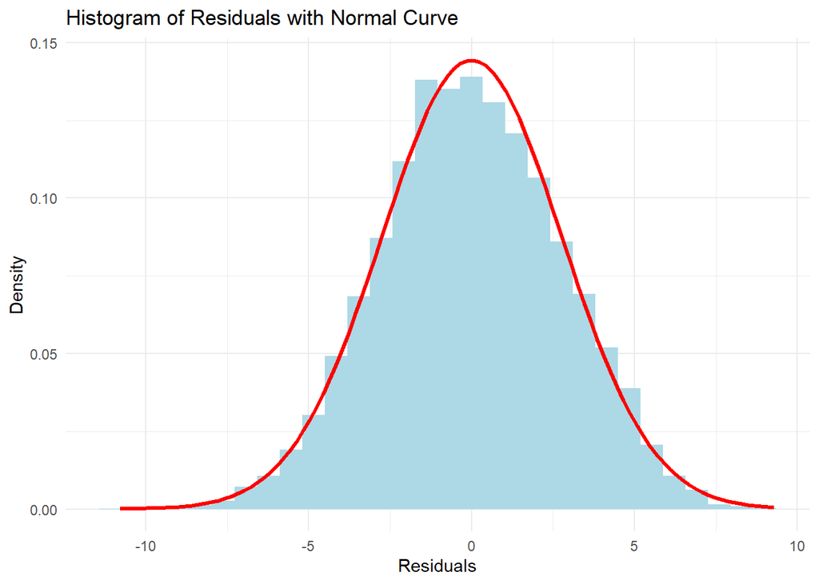

```r
# Histogram with bell curve and kurtosis
ggplot(temps, aes(x = RESID)) +
  geom_histogram(aes(y = after_stat(density)), fill = "lightblue", bins = 30) +
  stat_function(fun = dnorm, args = list(mean = mean(temps$RESID), sd = sd(temps$RESID)),
                color = "red", linewidth = 1.2) +
  # geom_vline(xintercept = skewness(temps$RESID)[1], linetype = "dashed", linewidth=1, color = "darkred")+
  labs(title = "Histogram of Residuals with Normal Curve", x = "Residuals", y = "Density",
        # subtitle = "Vertical line is kurtosis"
        )
```

# 5 Ornstein-Uhlenbeck (OU) process

Temperature dynamics using a mean-reverting stochastic process like the Ornstein-Uhlenbeck (OU) process, incorporate the seasonal adjustment into the drift rate to ensure that the expected value of the temperature follows the seasonal mean temperature.

The Ornstein-Uhlenbeck (OU) process is a type of stochastic (random) process that is often used in physics, finance, and other fields to model systems that exhibit some form of “mean-reverting” behavior. Let’s start from the basics to understand what this means.

A stochastic process is a collection of random variables representing the evolution of a system over time. In simpler terms, it describes how something changes when randomness is involved. For example, the price of a stock or the position of a particle under the influence of random forces can be modeled as a stochastic process.

$$dX_t = \kappa (\mu−X_t) \ d_t + \sigma \cdot dW_t$$

- $X_t$ is the value of the process at time t.
- $\mu$ is the long-term mean or equilibrium level toward which the process reverts.
- $\theta>0$ is the rate of mean reversion, determining how fast the process reverts to the mean P.
- $\sigma >0$ is the volatility or the intensity of the random fluctuations.
- $dW_t$ is an infinitesimal increment of a Wiener process (Brownian motion).

**Mean Reversion Term:** $\kappa (\mu−X_t) \ d_t$ : Representing the tendency of the process to revert to the mean $\mu$. If $X_t$is above the mean $\mu$, this term will be negative (pulling it down toward the mean). If $X_t$ is below $\mu$, the term will be positive (pushing it up toward the mean).

The speed of this pull or push is determined by $\kappa$. A higher $\kappa$ means the process will revert to the mean faster.

**Random Fluctuation Term** $\sigma \cdot dW_t$ : represents the random noise or shock. This is a source of randomness, and it causes the process to deviate randomly over time.

The size of the noise is controlled by $\sigma$, which is the volatility parameter.

```r
temps_OU <- temps
# Define parameters for the OU process
kappa <- 1-arima(temps_OU$RESID, order = c(1,0,0))$coef[1]  # Mean-reversion rate
sigma <- sd(temps$RESID, na.rm = TRUE)                      # Volatility of the process
dt <- 1                                                     # Time step (daily data)

cat("Kappa is estimated as:", round(kappa,4))
```

```
Kappa is estimated as: 0.2261
```

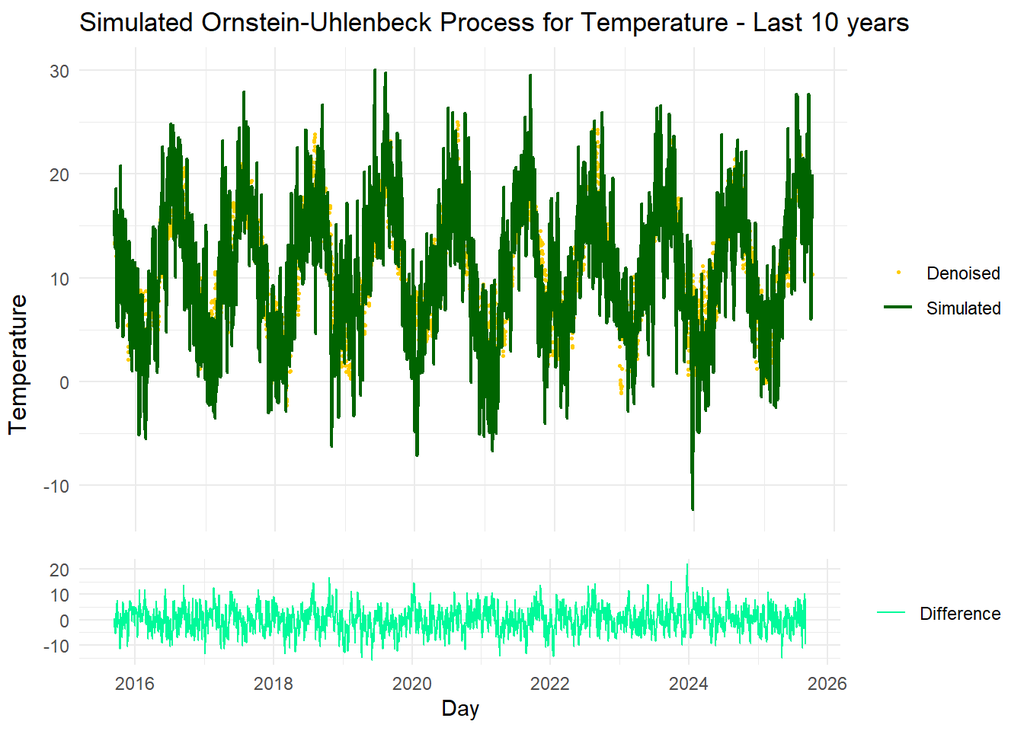

```r
# Initialize variables for simulation
n <- nrow(temps_OU)                      # Number of time points
T_simulated <- numeric(n)                # Simulated temperature vector
T_simulated[1] <- temps_OU$Denoised[1]   # Set initial temperature to the first observed value

# Simulate the seasonal mean as a time-varying mean (trend + seasonal component)
T_bar <- temps_OU$BAR

# Simulate the modified OU process
for (i in 2:n) {
  # Rate of change of the seasonal mean
  dT_bar_dt <- (T_bar[i] - T_bar[i - 1]) / dt

  # Brownian motion increment
  dWt <- rnorm(1, mean = 0, sd = sqrt(dt))

  T_simulated[i] <- T_simulated[i - 1] +
                    (dT_bar_dt + kappa * (T_bar[i] - T_simulated[i - 1])) * dt +
                    sigma * dWt
}

temps_OU$OU <- T_simulated

DATE <- tail(temps$DAY, lookback)

grid.arrange(layout_matrix = matrix(data = c(1,1,1,2), ncol = 1), left = "Temperature",
temps_OU %>%
  select(Denoised, OU, BAR) %>%
  tail(lookback) %>%
  ggplot(aes(x = DATE)) +
  geom_point(aes(y = Denoised, color = "Denoised"), size = 0.5) +
  geom_line(aes(y = OU, color = "Simulated"), linewidth = 0.8) +
  scale_color_manual(name = NULL, values = c(Denoised = "#ffcc00", Simulated = "darkgreen")) +
  labs(title = "Simulated Ornstein-Uhlenbeck Process for Temperature - Last 10 years", x = NULL, y = NULL)+
  theme(axis)+
  theme(axis.title.x = element_blank(),
        axis.text.x = element_blank(),
        axis.ticks.x = element_blank())
,
temps_OU %>%
  select(Denoised, OU, BAR) %>%
  tail(lookback) %>%
  ggplot(aes(x = DATE)) +
  geom_line(aes(y = Denoised-OU, color = "Difference"), linewidth = 0.5) +
  scale_color_manual(name = NULL, values = c(Difference = "mediumspringgreen")) +
  labs(x = "Day", y = NULL)
)
```

# 6 Modeling volatility

Now that i have the deterministic part of the model complete I need to model the volatility the first step was looking if there is any relation between day-of-year and volatility across the days of the year to try and model.

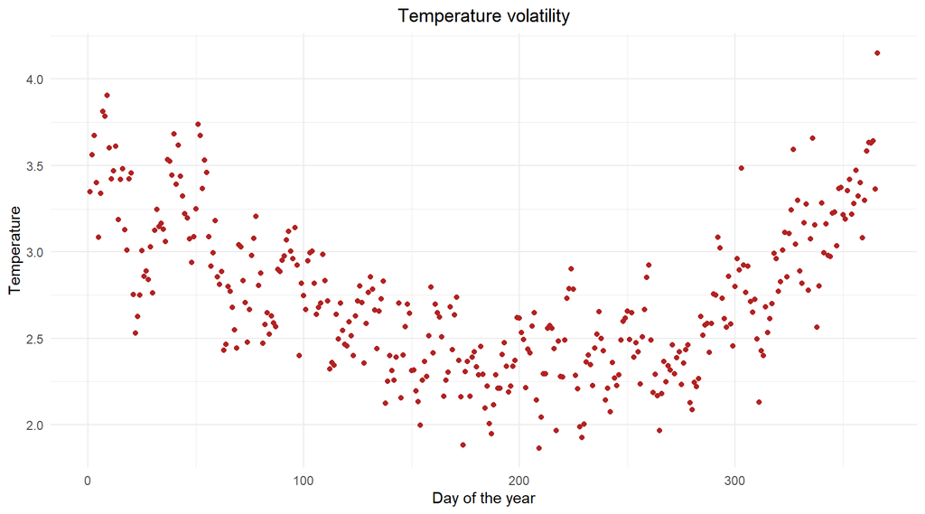

```r
# Create a dataframe with temperature and date components
temp_t <- data.frame(
  Date = temps$DAY,  # Assuming the index is a proper Date object
  T = temps$Denoised,
  day = yday(temps$DAY),
  month = month(temps$DAY)
)

vol_df <- temps %>%
  select(DAY, T_AVG) %>%
  mutate(day = yday(DAY),
        month = month(DAY)) %>%
  group_by(day) %>%
  summarise(mean = mean(T_AVG, na.rm = TRUE),
            std = sd(T_AVG, na.rm = TRUE))

# just a shorthand for reference
x <- 1:366
y <- vol_df$std

quickplot(vol_df$std, type = geom_point, show_legend = F, xlab = "Day of the year", ylab = "Temperature", title = "Temperature volatility")
```

The volatilty definitely has a shape and so we can try and model it with a deterministic model. There are many models to try and use, I’m trying a bunch to be thorough:

- Polynomial regression
- Fourier transformation
- B-splines
- Kernel smoothing
- Loess modeling
- Generalized additive modelling

A good way is to look at both fit and complexity-adjusted metrics: - Akaike Information Criterion (AIC): Helps select the best model by balancing goodness-of-fit and complexity by including the number of parameters alongside the log-likelihood in its calculation. - The residual sum of squares (RSS) measures the level of variance in the error term, or residuals, of a regression model. The smaller the residual sum of squares, the better your model fits your data; the greater the residual sum of squares, the poorer your model fits your data. - Visual inspection: sometimes a model with slightly worse AIC is much smoother/interpretable.

## 6.1 Polynomial Regression:

Polynomial regression is an extension of linear regression where the relationship between the independent variable(s) and the dependent variable is modeled as an $n-th$ degree polynomial. Polynomial regression allows for curvature by adding higher-order terms:
$$y = \beta_0 + \beta_1 x + \beta_2 x^2 + \cdots + \beta_d x^d + \epsilon$$

where $d$ is the degree of the polynomial.

These patterns are non-linear, so a simple straight-line regression won’t capture them.

Polynomial regression lets you fit a smooth curve that adapts to rises and falls over the 366 days.

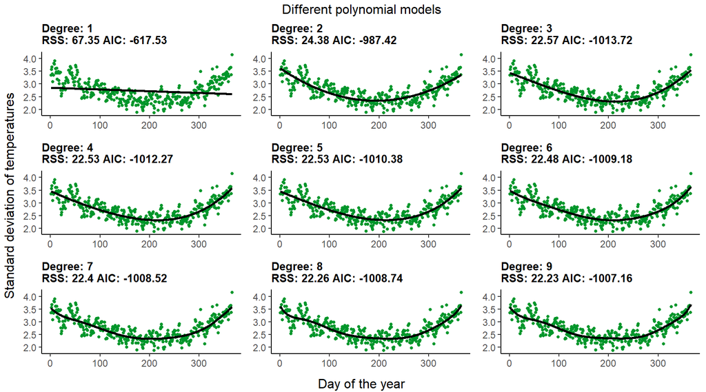

```r
create_poly_plot <- function(degree, x, y) {
  # Fit polynomial model
  model <- lm(y ~ poly(x, degree, raw = TRUE))
  yfit <- predict(model, data.frame(x = x))

  rss <- sum(resid(model)^2)
  n <- 366
  aic <- n*log(rss/n)+2*degree

  plot <- ggplot() +
    geom_point(aes(x, y), color = '#00962B', size = 1) +
    geom_line(aes(x, yfit), color = 'black', linewidth = 1) +
    ggtitle(paste("Degree:", degree, "\nRSS:", round(rss, 2), "AIC:", round(aic, 2))) +
    labs(y = NULL, x = NULL) +
    theme_classic() +
    theme(plot.title = element_text(size = 10, face = "bold"))

  return(list(
    plot = plot,
    degree = degree,
    rss = rss,
    aic = aic
  ))
}

degrees <- 1:9
results <- lapply(degrees, create_poly_plot, x = x, y = y)

# Extract plots
plots <- lapply(results, function(x) x$plot)

grid.arrange(grobs = plots, nrow = 3, ncol = 3, left = "Standard deviation of temperatures", bottom = "Day of the year", top = "Different polynomial models")
```

```r
# Extract metrics into a data frame
poly_metrics_df <- data.frame(
  parameter = sapply(results, function(x) x$degree),
  rss = sapply(results, function(x) x$rss),
  aic = sapply(results, function(x) x$aic)) %>%
    set_rownames(paste0("Polynomial",1:9))
```

## 6.2 Fourier transforms

The Fourier transform is a mathematical technique that breaks down any signal (like your volatility over days) into a sum of sinusoids (sines and cosines) at different frequencies.
$$f(x) \approx a_0 + \sum_{k=1}^n \big( a_k \cos(2\pi kx/T) + b_k \sin(2\pi kx/T) \big)$$

for this application I’m not changing the Amplitude (Strength of each frequency component), or Phase (Timing offset of each component) opting to just increase the order

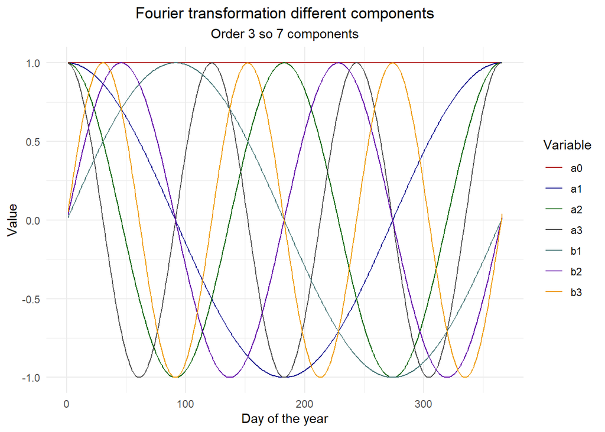

```r
fourier_series <- function(x, n_terms, period = 365.25) {
  omega <- 2 * pi / period
  terms <- list(a0 = 1)

  for (i in 1:n_terms) {
    terms[[paste0("a", i)]] <- cos(i * omega * x)
    terms[[paste0("b", i)]] <- sin(i * omega * x)
  }
  return(terms)
}

fourier_series(1:366, 3) %>%
  data.frame() %>%
    quickplot(title = "Fourier transformation different components",
    subtitle = "Order 3 so 7 components",
    xlab = "Day of the year"
  )
```

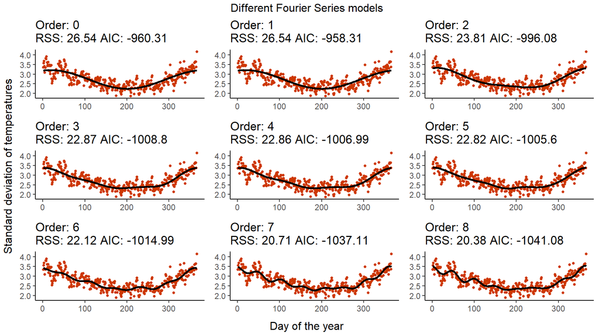

```r
create_fourier_plot <- function(n_terms, x, y) {
  # Fit Fourier series
  fourier_terms <- fourier_series(1:366, n_terms = n_terms)
  model_data <- data.frame(y = y, fourier_terms)

  fourier_fit <- lm(y ~ ., data = model_data)
  fourier <- predict(fourier_fit, newdata = model_data)

  rss <- sum(resid(fourier_fit)^2)
  n <- 366
  aic <- n*log(rss/n)+2*n_terms

  plot <- ggplot(data = data.frame(), aes(x = x)) +
    geom_point(aes(y = y), color = 'orangered3', size = 1) +
    geom_line(aes(y = fourier), color = 'black', linewidth = 1) +
    ggtitle(paste("Order:", n_terms, "\nRSS:", round(rss, 2), "AIC:", round(aic, 2))) +
    labs(y = NULL, x = NULL) +
    theme_classic()

    # Return both plot and metrics
  return(list(
    plot = plot,
    order = n_terms,
    rss = rss,
    aic = aic
  ))
}

order <- c(0:8)

results <- lapply(order, create_fourier_plot, x = x, y = y)

plots <- lapply(results, function(x) x$plot)

grid.arrange(grobs = plots, nrow = 3, ncol = 3,
  left = "Standard deviation of temperatures",
  bottom = "Day of the year",
  top = "Different Fourier Series models")
```

```r
# Extract metrics into a data frame
fourier_metrics_df <- data.frame(
  parameter = sapply(results, function(x) x$order),
  rss = sapply(results, function(x) x$rss),
  aic = sapply(results, function(x) x$aic)) %>%
    set_rownames(paste0("Fourier",1:9))
```

## 6.3 B-splines

B-splines create smooth curves by joining together piecewise polynomials at specific points called “knots.” Think of it as drawing a smooth curve through control points, in this case Equally spaced knots, where each piece is a simple polynomial. It is a model with excellent numerical stability (very hard to create overfittting)

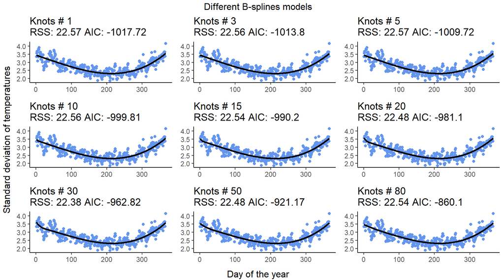

```r
library(splines)
create_spline_plot <- function(knots, x, y) {
  # Fit the spline model
  spline_model <- lm(y ~ bs(x, knots = knots))
  yfit <- predict(spline_model, data.frame(x = x))

  rss <- sum((y - yfit)^2)
  aic <- length(x) * log(rss / length(x)) + 2 * knots

  plot <- ggplot() +
    geom_point(aes(x, y), color = 'cornflowerblue', size = 1.5) +
    geom_line(aes(x, yfit), color = 'black', linewidth = 1) +
    ggtitle(paste("Knots #", knots, "\nRSS:", round(rss, 2), "AIC:", round(aic,2))) +
    labs(x = NULL, y = NULL) +
    theme_classic()

  # Return both plot and metrics
  return(list(
    plot = plot,
    knots = knots,
    rss = rss,
    aic = aic
  ))
}

knots <- c(1, 3, 5, 10, 15, 20, 30, 50, 80)
results <- lapply(knots, create_spline_plot, x = x, y = y)

plots <- lapply(results, function(x) x$plot)

grid.arrange(grobs = plots, nrow = 3, ncol = 3, left = "Standard deviation of temperatures", bottom = "Day of the year", top = "Different B-splines models")
```

```r
spline_metrics_df <- data.frame(
  parameter = sapply(results, function(x) x$knots),
  rss = sapply(results, function(x) x$rss),
  aic = sapply(results, function(x) x$aic)
) %>%
    set_rownames(paste0("B-Spline",1:9))
```

## 6.4 Kernel smoothing

Kernel regression creates smooth predictions by taking weighted averages of nearby data points. Points closer to the prediction location get higher weights, creating a locally-adapted smooth curve, also known as the Nadaraya-Watson estimator.

$$\hat y(x) = \sum_i^n w_i(x) * y_i$$

where $w(x)$ is the weights function in this case I’m using a gaussian kernel $K(u)=exp\left(−\frac12u^2\right)$

the bandwidth (h) is the control term Small h: More wiggly, follows data closely (high variance, low bias) Large h: Smoother, averages over more points (low variance, high bias)

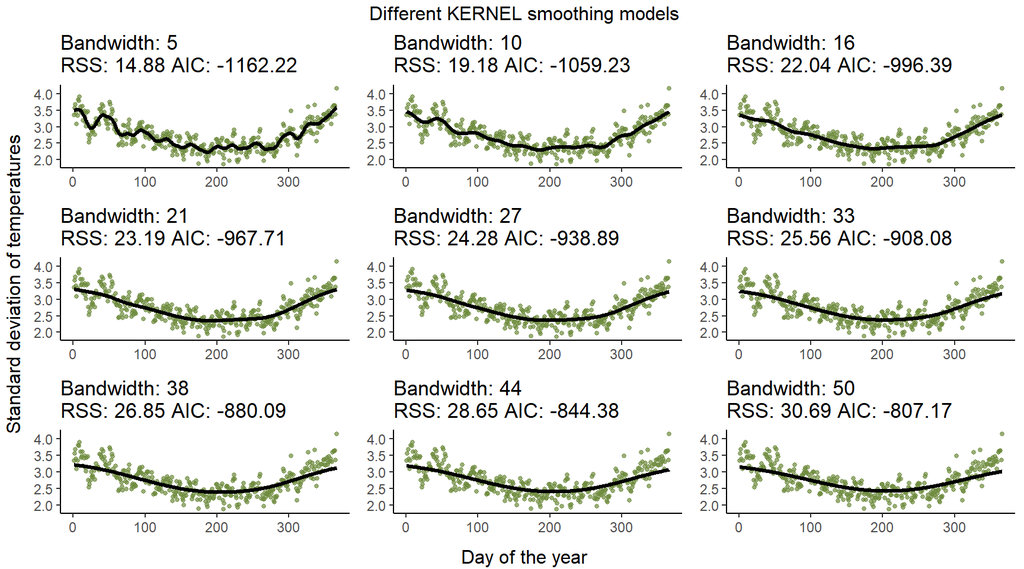

```r
kernel_smooth <- function(x_eval, x_data, y_data, h_val=10) {
    weights <- exp(-0.5 * ((x_eval - x_data) / h_val)^2)
    weights <- weights / sum(weights)
    return(sum(weights * y_data))
}

create_kernel_plot <- function(x, y, bandwidth) {
  y_pred <- sapply(x, function(xi) kernel_smooth(xi, x, y, bandwidth))

  rss <- sum((y - y_pred)^2)
  n <- length(y)
  aic <- n * log(rss/n) + 2*bandwidth

  data_plot <- data.frame(x = x, y = y, y_pred = y_pred)

  plot <- ggplot(data_plot, aes(x = x)) +
    geom_point(aes(y = y), color = 'darkolivegreen4', size = 1, alpha = 0.7) +
    geom_line(aes(y = y_pred), color = 'black', linewidth = 1.2) +
    ggtitle(paste("Bandwidth:", bandwidth, "\nRSS:", round(rss, 2), "AIC:", round(aic, 2))) +
    labs(y = NULL, x = NULL) +
    theme_classic()
  return(list(plot = plot, rss = rss, aic = aic, bandwidth = bandwidth))
}

width <- floor(seq(5, 50, length.out = 9))
results <- lapply(width, create_kernel_plot, x = x, y = y)

# Extract plots
plots <- lapply(results, function(x) x$plot)

grid.arrange(grobs = plots, nrow = 3, ncol = 3,
            left = "Standard deviation of temperatures",
            bottom = "Day of the year",
            top = "Different KERNEL smoothing models")
```

```r
# Extract metrics into data frame
kernel_metrics_df <- data.frame(
  parameter = sapply(results, function(x) x$bandwidth),
  rss = sapply(results, function(x) x$rss),
  aic = sapply(results, function(x) x$aic)) %>%
    set_rownames(paste0("Kernel-smoothing",1:9))
```

## 6.5 Loess modelling

LOESS fits a smooth curve by performing many small linear or quadratic regressions on local neighborhoods of data points. At each point, it gives more weight to nearby observations and less to distant ones. For each point x₀, define a neighborhood containing the $α$ fraction of closest points (span parameter)

- Small span: More wiggly, follows data closely
- Large span: Smoother, more global averaging

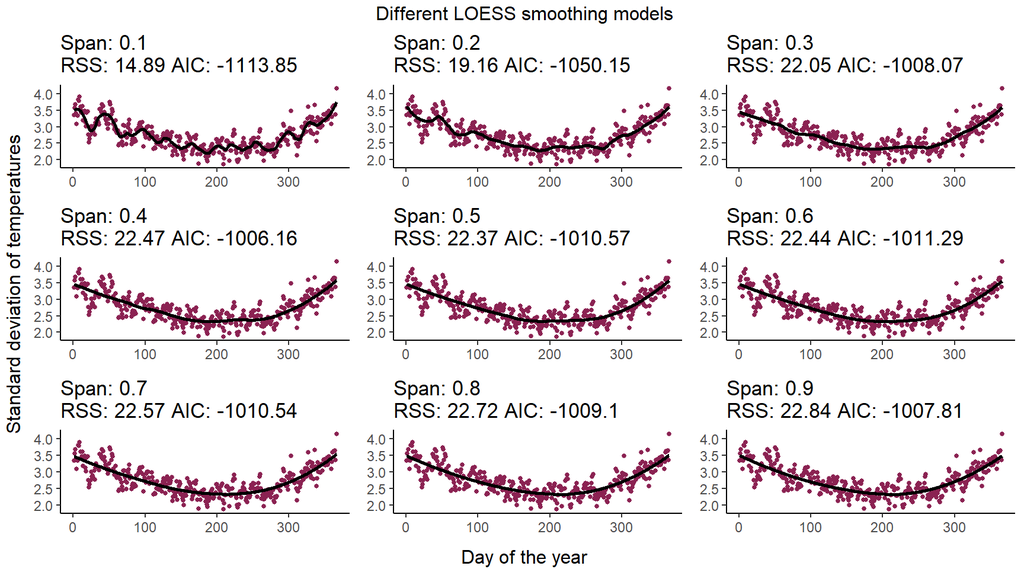

```r
create_loess_plot <- function(span_val, x, y) {
  # Fit LOESS model
  loess_fit <- loess(y ~ x, span = span_val)
  loess_pred <- predict(loess_fit, newdata = data.frame(x = x))

  rss <- sum((y - loess_pred)^2)

  # Effective degrees of freedom from loess
  df <- loess_fit$enp  # "equivalent number of parameters"
  n <- 366
  aic <- n * log(rss/n) + 2 * df

  plot <- ggplot(data = data.frame(x = x, y = y, fit = loess_pred), aes(x = x)) +
    geom_point(aes(y = y), color = 'violetred4', size = 1) +
    geom_line(aes(y = fit), color = 'black', linewidth = 1) +
    ggtitle(paste("Span:", span_val, "\nRSS:", round(rss, 2), "AIC:", round(aic, 2))) +
    labs(y = NULL, x = NULL) +
    theme_classic()

  # Return both plot and metrics
  return(list(
    plot = plot,
    span = span_val,
    rss = rss,
    aic = aic
  ))
}

spans <- seq(0.1, 0.9, by = 0.1)
results <- lapply(spans, create_loess_plot, x = x, y = y)

# Extract plots
plots <- lapply(results, function(x) x$plot)

grid.arrange(grobs = plots, nrow = 3, ncol = 3,
            left = "Standard deviation of temperatures",
            bottom = "Day of the year",
            top = "Different LOESS smoothing models")
```

```r
# Extract metrics into data frame
loess_metrics_df <- data.frame(
  parameter = sapply(results, function(x) x$span),
  rss = sapply(results, function(x) x$rss),
  aic = sapply(results, function(x) x$aic)) %>%
    set_rownames(paste0("LOESS",1:9))
```

## 6.6 GAM

GAM models fit smooth, flexible curves to data by combining multiple smooth functions instead of assuming a specific parametric form. Think of it as “flexible regression” that can capture complex patterns without forcing them into straight lines or simple curves. A basis functions is needed to control the curvature, I’m using as the basis functions cyclic cubic regression splines `bs = "cc"`, a penalized cubic regression splines up to second derivative.
$$y = β_0 + f_1(x_1) + f_2(x_2) + ε$$

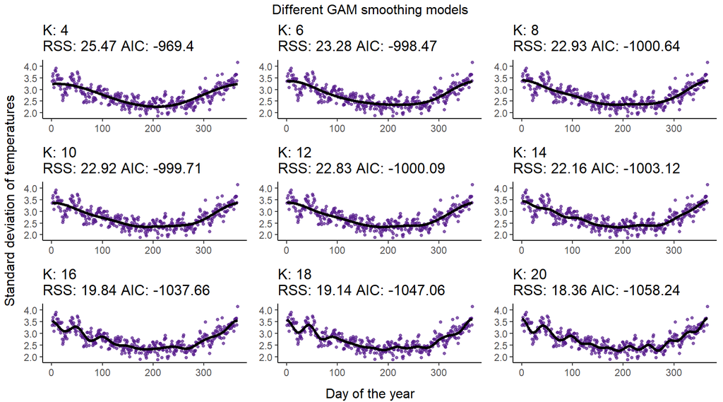

```r
library(mgcv, warn.conflicts = F, quietly = T)
create_gam_plot <- function(x, y, k_value) {
  # Fit GAM with cyclic smooth for seasonal data
  gam_model <- gam(y ~ s(x, bs = "cc", k = k_value), weights = rep(1, length(y)))
  y_pred <- predict(gam_model)

  rss <- sum((y - y_pred)^2)
  n <- 366
  edf <- sum(gam_model$edf)  # effective degrees of freedom
  aic <- n * log(rss/n) + 2 * edf

  data_plot <- data.frame(x = x, y = y, y_pred = y_pred)

  plot <- ggplot(data_plot, aes(x = x)) +
    geom_point(aes(y = y), color = 'purple4', size = 1, alpha = 0.7) +
    geom_line(aes(y = y_pred), color = 'black', linewidth = 1.2) +
    ggtitle(paste("K:", k_value, "\nRSS:", round(rss, 2),
                  "AIC:", round(aic, 2))) +
    theme_classic() +
    labs(y = NULL, x = NULL)

  return(list(plot = plot, k_value = k_value, rss = rss, aic = aic))
}

k_values <- floor(seq(4, 20, length.out = 9))
results <- lapply(k_values, create_gam_plot, x = x, y = y)

# Extract plots
plots <- lapply(results, function(x) x$plot)

grid.arrange(grobs = plots, nrow = 3, ncol = 3,
            left = "Standard deviation of temperatures",
            bottom = "Day of the year",
            top = "Different GAM smoothing models")
```

```r
# Extract metrics into data frame
gam_metrics_df <- data.frame(
  parameter = sapply(results, function(x) x$k_value),
  rss = sapply(results, function(x) x$rss),
  aic = sapply(results, function(x) x$aic)) %>%
    set_rownames(paste0("GAM",1:9))
```

## 6.7 Figuring out which is the best model

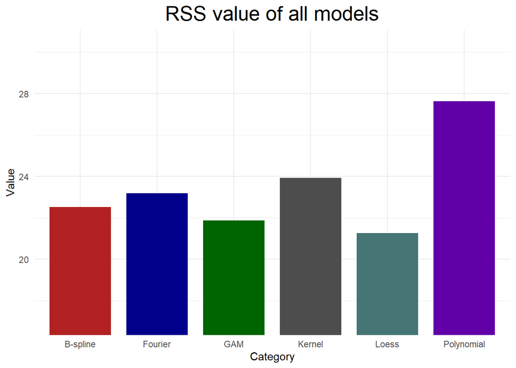

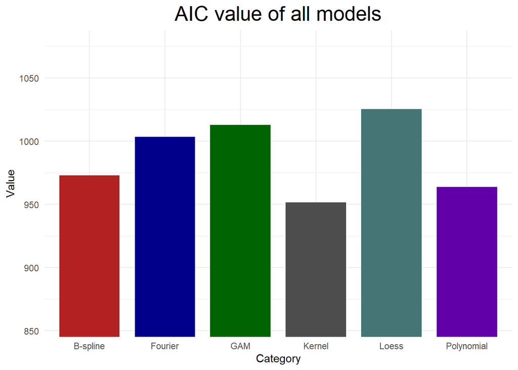

Best model according to AIC

|  | Parameter | RSS | AIC |
| --- | --- | --- | --- |
| Kernel-smoothing1 | 5.0 | 14.87746 | -1162.220 |
| LOESS1 | 0.1 | 14.88682 | -1113.848 |
| Kernel-smoothing2 | 10.0 | 19.18078 | -1059.233 |
| GAM9 | 20.0 | 18.36132 | -1058.245 |
| LOESS2 | 0.2 | 19.15993 | -1050.153 |
| GAM8 | 18.0 | 19.14058 | -1047.058 |

Best model according to RSS

|  | Parameter | RSS | AIC |
| --- | --- | --- | --- |
| Kernel-smoothing1 | 5.0 | 14.87746 | -1162.220 |
| LOESS1 | 0.1 | 14.88682 | -1113.848 |
| GAM9 | 20.0 | 18.36132 | -1058.245 |
| GAM8 | 18.0 | 19.14058 | -1047.058 |
| LOESS2 | 0.2 | 19.15993 | -1050.153 |
| Kernel-smoothing2 | 10.0 | 19.18078 | -1059.233 |

```r
comparison_df <- rbind(
  poly_metrics_df,
  fourier_metrics_df,
  spline_metrics_df,
  kernel_metrics_df,
  loess_metrics_df,
  gam_metrics_df
) %>%
  set_colnames(c("Parameter", "RSS", "AIC"))


summary_comparison_df <- data.frame()

for (i in 1:6) {
  summary_comparison_df <- rbind(
    summary_comparison_df,
    (apply(comparison_df[seq((i - 1) * 9 + 1, 9 * i), ], 2, mean))
  )
}
summary_comparison_df[, 1] <- c(
  "Polynomial",
  "Fourier",
  "B-spline",
  "Kernel",
  "Loess",
  "GAM"
)
colnames(summary_comparison_df) <- c("Model", "RSS", "AIC")
summary_comparison_df$AIC <- abs(summary_comparison_df$AIC)


summary_comparison_df$RSS %>%
  set_names(summary_comparison_df$Model) %>%
  quickbarplot(title = "RSS value of all models", palette = "navyblue") +
  theme(plot.title = element_text(size = 20)) +
  coord_cartesian(
    ylim = c(
      min(summary_comparison_df$RSS) * 0.8,
      max(summary_comparison_df$RSS) * 1.1
    )
  )
summary_comparison_df$AIC %>%
  set_names(summary_comparison_df$Model) %>%
  quickbarplot(title = "AIC value of all models", palette = "darkred") +
  theme(plot.title = element_text(size = 20)) +
  coord_cartesian(
    ylim = c(
      min(summary_comparison_df$AIC) * 0.9,
      max(summary_comparison_df$AIC) * 1.05
    )
  )
head(comparison_df[order(comparison_df$AIC), ]) %>%
  gt(rownames_to_stub = T) %>%
  opt_stylize(5, color = "blue") %>%
  tab_header("Best model according to AIC")
head(comparison_df[order(comparison_df$RSS), ]) %>%
  gt(rownames_to_stub = T) %>%
  opt_stylize(5, color = "green") %>%
  tab_header("Best model according to RSS")
best_model <- comparison_df[which.min(comparison_df$AIC), ]
best_model_name <- gsub("[0-9]", "", (rownames(best_model)))
parameter <- switch(best_model_name,
  "Polynomial" = "degrees",
  "Fourier" = "order",
  "B-Spline" = "knots",
  "Kernel-smoothing" = "bandwidth",
  "LOESS" = "span",
  "GAM" = "k values",
  stop("Unknown model: ", best_model_name) # error
)
```

so the best model is Kernel-smoothing with bandwidth = 5. it has the lowest AIC at -1162.22 value and the best RSS at 14.88. so moving forward I will use that for the volatility modeling.

```r
# 3. Print long-term volatility metrics
cat("Trend or long term volatility ~", round(mean(vol_df$std, na.rm = TRUE), 3), "\n")
```

```
Trend or long term volatility ~ 2.73
```

```r
cat("Gamma is ~", round(sd(vol_df$std, na.rm = TRUE), 3), "\n")
```

```
Gamma is ~ 0.436
```

```r
# 4. Fit AR(1) model for mean reversion rate
ar_model <- arima(vol_df$std, order = c(1, 0, 0), include.mean = FALSE)
coef <- ar_model$coef
residuals <- ar_model$residuals

cat("Rate of mean reversion of volatility process is:", round(coef["ar1"], 3), "\n")
```

```
Rate of mean reversion of volatility process is: 0.998
```

```r
summary(ar_model)
```

```
Call:
arima(x = vol_df$std, order = c(1, 0, 0), include.mean = FALSE)

Coefficients:
         ar1
      0.9977
s.e.  0.0026

sigma^2 estimated as 0.05128:  log likelihood = 21.58,  aic = -39.15

Training set error measures:
                      ME     RMSE       MAE         MPE     MAPE     MASE
Training set 0.009025571 0.226445 0.1775325 -0.04251562 6.595296 1.001041
                   ACF1
Training set -0.1478413
```

# 7 Montecarlo simulations

With the volatility component now modelled and a satisfactory result pulled from it it’s time to move to the actual Montecarlo simulations for the temperature come the maturity date next year

so starting from our model both the deterministic component as well as the volatilty component need to be simulated and added to create the full simulated dataset from all our previous work

using the Euler scheme approximation step in our modified Ornstein-Uhlenbeck model for temperature simulations

$$dT_t=\left(\frac{dT_{bar}(t)}{dt}+κ(T_{bar}(t)−T_t)\right)dt + σ(t)\ dW_t$$

```r
a <- MOD_params[1]
b <- MOD_params[2]
theta <- atan2(MOD_params[3], MOD_params[4])
alpha <- sqrt(MOD_params[3]^2 + MOD_params[4]^2)
kappa <- as.double(kappa)

data.frame(a = a, b = b, theta = theta, alpha = alpha, kappa = kappa) %>%
  set_rownames("value")
```

|  | a | b | theta | alpha | kappa |
| --- | --- | --- | --- | --- | --- |
| value | 9.532908 | 9.79e-05 | -2.217757 | 8.539706 | 0.226139 |

```r
# Temperature Model Functions
T_model <- function(x, a, b, alpha, theta) {
  omega <- 2 * pi / 365.25
  a + b * x + alpha * sin(omega * x + theta)
}
dT_model <- function(x, a, b, alpha, theta) {
  omega <- 2 * pi / 365.25
  b + alpha * omega * cos(omega * x + theta)
}

# Apply Model with Given Parameters
Tbar_params <- list(a = a, b = b, alpha = alpha, theta = theta)
temp_t$ordinal <- as.numeric(temps$DAY) - as.numeric(temps$DAY[1]) # x values
first_ordinal_val <- as.numeric(temps$DAY[1])

temps$model_fit <- T_model(
  temp_t$ordinal,
  Tbar_params$a,
  Tbar_params$b,
  Tbar_params$alpha,
  Tbar_params$theta
)
```

At this point we care more about the distribution than any single point not if there is auto-correlation in the residuals

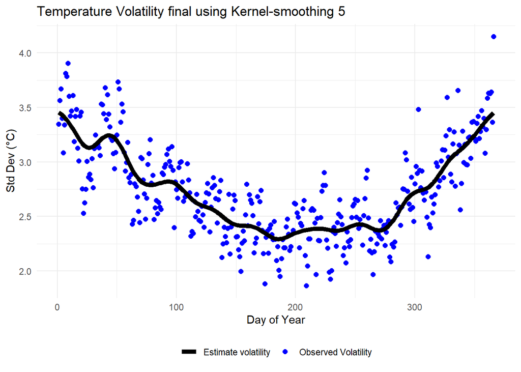

```r
# Big switch function to get the correct model VALUES
fit_volatility <- switch(
  best_model_name,
  "Polynomial" = {
    yfit <- predict(lm(y ~ poly(x, parameter, raw = TRUE)), data.frame(x = x))
  },
  "Fourier" = {
    model_data <- data.frame(y = y, fourier_series(1:366, n_terms = parameter))
    fourier_fit <- lm(y ~ ., data = model_data)
    yfit <- predict(fourier_fit, newdata = model_data)
  },
  "B-Spline" = {
    yfit <- predict(lm(y ~ bs(x, knots = parameter)), data.frame(x = x))
  },
  "Kernel-smoothing" = {
    yfit <- sapply(x, function(xi) kernel_smooth(xi, x, y, ))
  },
  "LOESS" = {
    loess_fit <-
      yfit <- predict(
        loess(y ~ x, span = parameter),
        newdata = data.frame(x = x)
      )
  },
  "GAM" = {
    yfit <- predict(gam(
      y ~ s(x, bs = "cc", k = parameter),
      weights = rep(1, length(y))
    ))
  },
  # Default: error if unknown type
  stop("Unknown model type: ", best_model_name)
)
vol_df$fvol <- yfit

# Plot Volatility
ggplot(vol_df, aes(x = day)) +
  geom_point(aes(y = std, color = "Observed Volatility"), size = 2) +
  geom_line(aes(y = fvol, color = "Estimate volatility"), size = 2) +
  scale_color_manual(
    NULL,
    values = c("Observed Volatility" = "blue", "Estimate volatility" = "black")
  ) +
  labs(
    title = paste(
      "Temperature Volatility final using",
      best_model_name,
      best_model$Parameter
    ),
    y = "Std Dev (°C)",
    x = "Day of Year"
  ) +
  theme_minimal() +
  theme(legend.position = "bottom")
```

Finally we can implement the functions for the simulation

```r
# REAL Monte Carlo Simulation Functions
euler_step <- function(row, kappa, M) {
  T_i <- ifelse(is.na(row$Tbar_shift), row$Tbar, row$Tbar_shift)
  T_det <- T_i + row$dTbar
  T_mrev <- kappa * (row$Tbar - T_i)
  sigma <- row$vol * rnorm(M)
  T_det + T_mrev + sigma
}

monte_carlo_temp <- function(trading_dates, Tbar_params, vol_df,
                            first_ordinal, M = 1, kappa = 0.226139) {
  # Convert dates to numeric if needed
  trading_numeric <- as.numeric(trading_dates)
  kappa_val <- as.double(kappa)

  # Calculate Tbar and dTbar
  x_vals <- trading_numeric - first_ordinal_val
  Tbars <- T_model(
    x_vals,
    Tbar_params$a,
    Tbar_params$b,
    Tbar_params$alpha,
    Tbar_params$theta
  )

  dTbars <- dT_model(
    x_vals,
    Tbar_params$a,
    Tbar_params$b,
    Tbar_params$alpha,
    Tbar_params$theta
  )

  # Create simulation dataframe
  mc_temps <- data.frame(
    Date = trading_dates,
    Tbar = Tbars,
    dTbar = dTbars,
    day = yday(trading_dates),
    vol = data.frame(vol_df)$fvol[yday(trading_dates)] # Directly add volatility
  )

  # Add lagged Tbar
  mc_temps$Tbar_shift <- dplyr::lag(mc_temps$Tbar)

  # Run simulations - modified apply call
  simulations <- sapply(1:nrow(mc_temps), function(i) {
    row <- mc_temps[i, ]
    euler_step(row, kappa_val, M)
  })

  # Transpose and format results
  simulations <- t(simulations)
  colnames(simulations) <- paste0("Sim", 1:M)

  list(
    mc_temps = mc_temps,
    mc_sims = cbind(Date = trading_dates, as.data.frame(simulations))
  )
}
```

I then decided to check performance in a couple of ways, first just a one year completed model to see how the performance fairs against both the stricter 5-95 percentile and also a fair but more generous $±2σ$ from the simulated volatility.

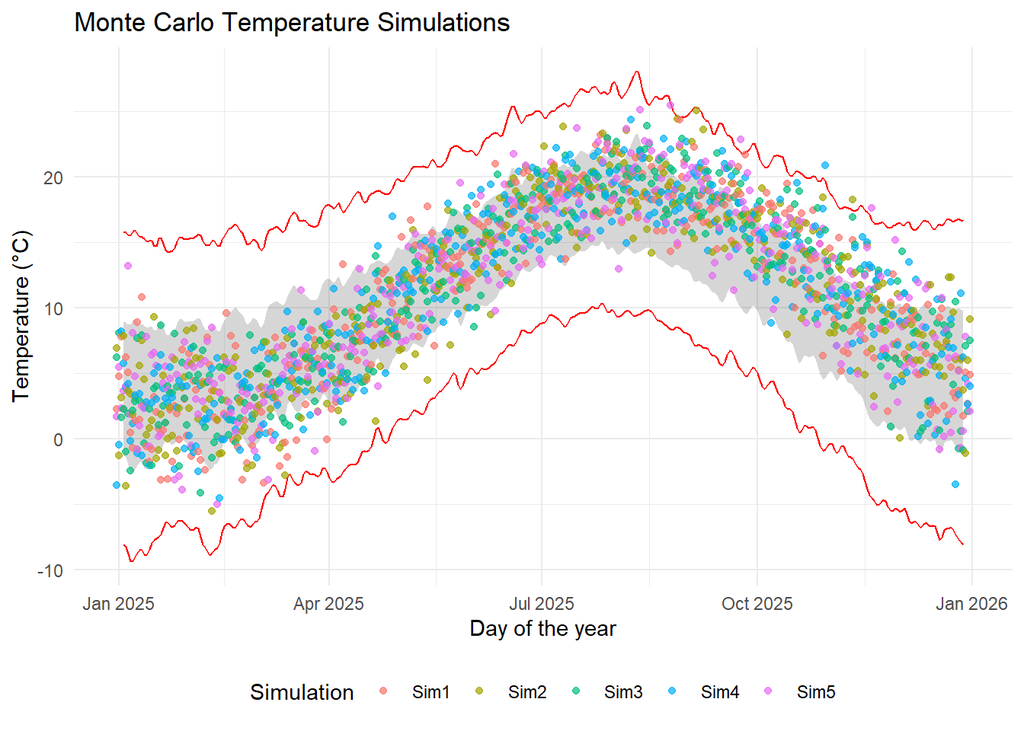

```r
# Run Simulation
one_year_trading_dates <- seq(as.Date("2024-12-31"), as.Date("2025-12-31"), by = "day")
sim_results <- monte_carlo_temp(
  one_year_trading_dates,
  Tbar_params,
  vol_df,
  first_ordinal_val,
  M = 5
)

piv_sim <- pivot_longer(sim_results$mc_sims, -Date, names_to = "Simulation", values_to = "Temperature")

MIN_MAX <- data.frame(
      "MIN" = apply_convolution(apply(pivot_df[-1], 1, quantile, 0.05 , na.rm = TRUE),dnorm(-3:3)),
      "MAX" = apply_convolution(apply(pivot_df[-1], 1, quantile, 0.95, na.rm = TRUE),dnorm(-3:3))
    )

suppressWarnings(
  ggplot() +
  geom_ribbon(data = MIN_MAX, aes(x = one_year_trading_dates, ymin = MIN, ymax = MAX), , alpha = 0.2) +
  geom_ribbon(data = MIN_MAX, aes(x = one_year_trading_dates, ymin = MIN-2*vol_df$fvol, ymax = MAX+2*vol_df$fvol), alpha = 0, color = "red") +
  geom_point(data = piv_sim, aes(x = Date, y = Temperature, color = Simulation), alpha = 0.7) +
labs(title = "Monte Carlo Temperature Simulations", y = "Temperature (°C)", x = "Day of the year") +
  guides(fill = "none") +
  theme(legend.position = "bottom"))
```

They are scattered across the historical envelope, which suggests:

- The simulations are plausible given past variability.
- There’s no extreme bias (e.g., all simulations too hot or too cold).
- The model accounts for natural variability and uncertainty.
- The simulated values mostly stay within the historical bounds (plausible since we are taking the effects of climate change variations)
- A slight seasonal shift with spring and summer starting a bit later than historically